# “Una nueva estimación objetiva de la dificultad técnica de una vídeo-colonoscopía con intubación cecal: The Argentina Brief Colonoscopy Difficulty (ABCD) score”

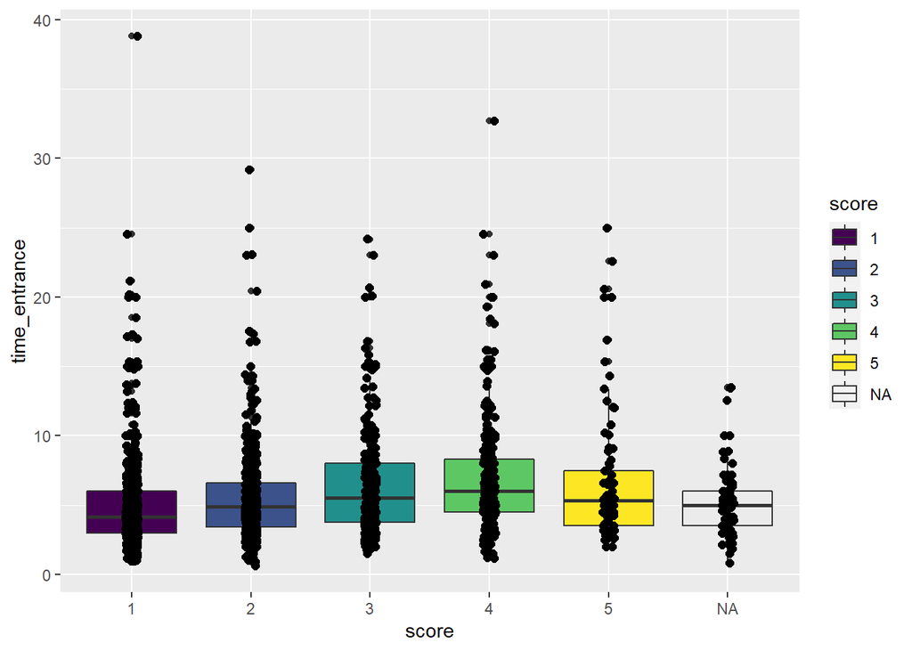

```r
ggplot(data = db_total, mapping = aes(x=score, y=time_entrance))+
  geom_boxplot(mapping = aes(fill=score))+
  geom_jitter(size=2, position = position_jitter(width = 0.05))#similar distribucion
```

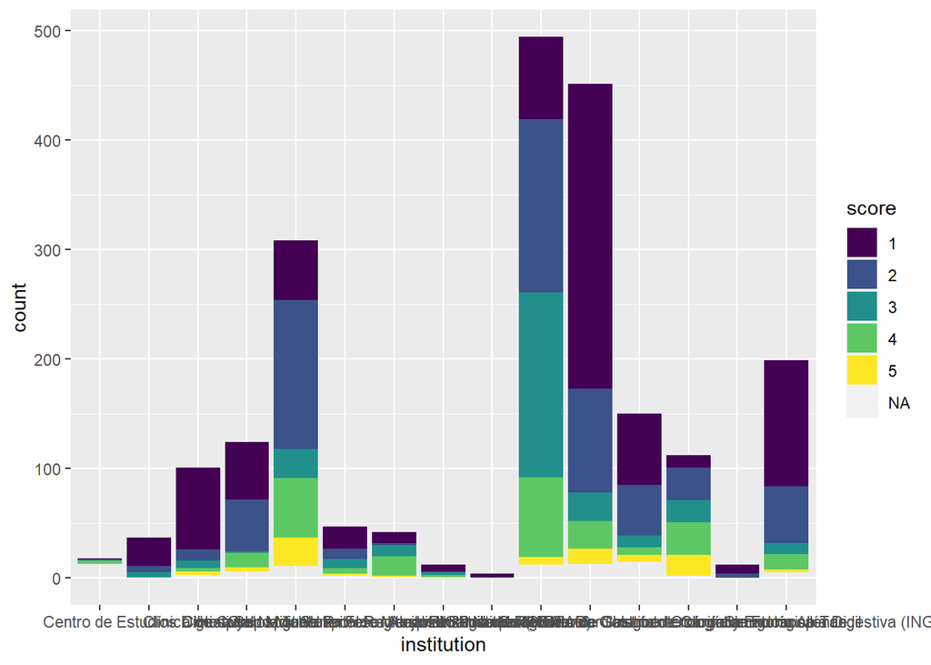

```r
#institucion:

ggplot(db_total, aes(institution))+
  geom_bar(aes(fill=score))
```

```r
table(db_total$institution,db_total$score)
```

```
##
##                                                                                 1
##                                                                                 1
##   Centro de Estudios Digestivos                                                26
##   Clínica de Cuyo                                                              75
##   Clínica San Miguel                                                           52
##   Grupo Mit Santa Fe                                                           54
##   Hospital Italiano de Mendoza                                                 20
##   Hospital Nacional Profesor Alejandro Posadas (HNPAP)                         10
##   Hospital Regional R Carrillo S del Estero                                     6
##   Hospital Regional Río Grande                                                  3
##   IGEA                                                                         75
##   Instituto Modelo de Cardiología de Córdoba                                  278
##   Instituto Modelo de Gastroenterologia de Formosa                             65
##   Instituto Norpatagónico de Gastroenterología y Endoscopía Digestiva (INGED)  11
##   Instituto Otorrinolaringológico Tandil                                        8
##   Sanatorio Allende                                                           115
##
##                                                                                 2
##                                                                                 1
##   Centro de Estudios Digestivos                                                 6
##   Clínica de Cuyo                                                              10
##   Clínica San Miguel                                                           48
##   Grupo Mit Santa Fe                                                          136
##   Hospital Italiano de Mendoza                                                 10
##   Hospital Nacional Profesor Alejandro Posadas (HNPAP)                          2
##   Hospital Regional R Carrillo S del Estero                                     1
##   Hospital Regional Río Grande                                                  1
##   IGEA                                                                        158
##   Instituto Modelo de Cardiología de Córdoba                                   95
##   Instituto Modelo de Gastroenterologia de Formosa                             46
##   Instituto Norpatagónico de Gastroenterología y Endoscopía Digestiva (INGED)  30
##   Instituto Otorrinolaringológico Tandil                                        4
##   Sanatorio Allende                                                            52
##
##                                                                                 3
##                                                                                 0
##   Centro de Estudios Digestivos                                                 4
##   Clínica de Cuyo                                                               7
##   Clínica San Miguel                                                            1
```

[output cut: 30 more lines]

```
##                                                                                 0
##   Centro de Estudios Digestivos                                                 0
##   Clínica de Cuyo                                                               3
##   Clínica San Miguel                                                            4
##   Grupo Mit Santa Fe                                                           26
##   Hospital Italiano de Mendoza                                                  2
##   Hospital Nacional Profesor Alejandro Posadas (HNPAP)                          1
##   Hospital Regional R Carrillo S del Estero                                     1
##   Hospital Regional Río Grande                                                  0
##   IGEA                                                                          7
##   Instituto Modelo de Cardiología de Córdoba                                   14
##   Instituto Modelo de Gastroenterologia de Formosa                              6
##   Instituto Norpatagónico de Gastroenterología y Endoscopía Digestiva (INGED)  19
##   Instituto Otorrinolaringológico Tandil                                        0
##   Sanatorio Allende                                                             3
```

```r
chi_hernia<-chisq.test(db_total$hernia,db_total$score)
chi_hernia$expected
```

```
##                db_total$score
## db_total$hernia         1         2          3          4         5
##              no 775.21087 579.69741 284.472084 237.548853 84.070788
##              si  17.78913  13.30259   6.527916   5.451147  1.929212
```

# 3 *Tabla 1*

```r
#Tabla1:

tabla_1<-tableby(score~kwt(age)+chisq(gender)+
                 kwt(bmi)+chisq(digestive_surgery)+fe(hernia)+
                 fe(prior_incomplete_colonoscopy)+
                 fe(ambulatory_hospitalised)+
                 chisq(indication_colonoscopy)+
                 chisq(preparation)+
                 chisq(first_operator_type)+
                 chisq(second_operator_type)+
                 chisq(schedule)+chisq(veda_vcc_conjunta)+
                 chisq(boston),data=db_total, numeric.stats=c("median","q1q3"),na.tableby(TRUE))

mylabels<-list(age="Edad",gender="Genero",bmi="IMC",digestive_surgery="Cirugia abdominal",hernia="Antecedentes de hernia",prior_incomplete_colonoscopy="Colonoscopia previa incompleta",ambulatory_hospitalised="Ambulatorio u hospitalizado",indication_colonoscopy="Indicacion de la colonoscopia",preparation="Preparacion colonica",operators="Cambio de endoscopista",first_operator_type="tipo de 1° operador",second_operator_type="Tipo de 2° operador",restart_within_single_operator="Reiniciar con otro operador",schedule="Momento de realizacion del procedimiento",veda_vcc_conjunta="VEDA- VCC conjunta",postural_changes="Cambios posturales",manual_pressure_more_than_five_seconds="Compresion abdominal mas de 5 seg",ileocecal_junction_visualization="Visualizacion del ciego",postural_changes="Cambios posturales", boston="Boston",time_entrance="Tiempo de entrada en min",pain="Dolor",consumption_propofol_mg="Consumo de propofol(mg)")

sum_tabla1<-summary(tabla_1, text=T,title = "Tabla 1. Caracteristicas basales y generales de la VCC segun categorias del score ABCD" , pfootnote=TRUE,labelTranslations =mylabels, digits = 2)
sum_tabla1
```

Tabla 1. Caracteristicas basales y generales de la VCC segun categorias del score ABCD

|  | 1 (N=799) | 2 (N=600) | 3 (N=295) | 4 (N=248) | 5 (N=86) | Total (N=2028) | p value |
| --- | --- | --- | --- | --- | --- | --- | --- |
| Edad |  |  |  |  |  |  | 0.003 (1) |
| - Median | 58.00 | 58.00 | 59.00 | 61.00 | 60.00 | 58.00 |  |
| - Q1, Q3 | 49.00, 66.00 | 49.00, 68.00 | 49.00, 71.00 | 51.00, 69.25 | 52.00, 72.00 | 49.00, 68.00 |  |
| Genero |  |  |  |  |  |  | < 0.001 (2) |
| - N-Miss | 3 | 7 | 1 | 2 | 0 | 13 |  |
| - hombre | 443 (55.7%) | 260 (43.8%) | 95 (32.3%) | 86 (35.0%) | 34 (39.5%) | 918 (45.6%) |  |
| - mujer | 353 (44.3%) | 333 (56.2%) | 199 (67.7%) | 160 (65.0%) | 52 (60.5%) | 1097 (54.4%) |  |
| IMC |  |  |  |  |  |  | < 0.001 (1) |
| - Median | 27.07 | 26.67 | 25.95 | 26.30 | 27.38 | 26.77 |  |
| - Q1, Q3 | 24.69, 29.97 | 24.20, 29.55 | 22.97, 28.70 | 23.55, 30.84 | 24.38, 30.57 | 24.22, 29.76 |  |
| Cirugia abdominal |  |  |  |  |  |  | 0.003 (2) |
| - N-Miss | 3 | 4 | 5 | 0 | 0 | 12 |  |
| - no | 473 (59.4%) | 346 (58.1%) | 161 (55.5%) | 119 (48.0%) | 38 (44.2%) | 1137 (56.4%) |  |
| - si | 323 (40.6%) | 250 (41.9%) | 129 (44.5%) | 129 (52.0%) | 48 (55.8%) | 879 (43.6%) |  |
| Antecedentes de hernia |  |  |  |  |  |  | 0.012 (3) |
| - N-Miss | 6 | 7 | 4 | 5 | 0 | 22 |  |
| - no | 783 (98.7%) | 582 (98.1%) | 280 (96.2%) | 232 (95.5%) | 84 (97.7%) | 1961 (97.8%) |  |
| - si | 10 (1.3%) | 11 (1.9%) | 11 (3.8%) | 11 (4.5%) | 2 (2.3%) | 45 (2.2%) |  |
| Colonoscopia previa incompleta |  |  |  |  |  |  | < 0.001 (3) |
| - N-Miss | 9 | 12 | 8 | 1 | 1 | 31 |  |
| - no | 774 (98.0%) | 576 (98.0%) | 275 (95.8%) | 234 (94.7%) | 77 (90.6%) | 1936 (96.9%) |  |
| - si | 16 (2.0%) | 12 (2.0%) | 12 (4.2%) | 13 (5.3%) | 8 (9.4%) | 61 (3.1%) |  |
| Ambulatorio u hospitalizado |  |  |  |  |  |  | 0.134 (3) |
| - N-Miss | 2 | 6 | 4 | 1 | 0 | 13 |  |
| - ambulatorio | 783 (98.2%) | 590 (99.3%) | 290 (99.7%) | 245 (99.2%) | 84 (97.7%) | 1992 (98.9%) |  |
| - hospitalizado | 14 (1.8%) | 4 (0.7%) | 1 (0.3%) | 2 (0.8%) | 2 (2.3%) | 23 (1.1%) |  |
| Indicacion de la colonoscopia |  |  |  |  |  |  | 0.316 (2) |
| - N-Miss | 1 | 2 | 2 | 1 | 0 | 6 |  |
| - screening ccr | 353 (44.2%) | 296 (49.5%) | 140 (47.8%) | 118 (47.8%) | 40 (46.5%) | 947 (46.8%) |  |
| - seguimiento | 150 (18.8%) | 105 (17.6%) | 44 (15.0%) | 46 (18.6%) | 11 (12.8%) | 356 (17.6%) |  |
| - diagnostica | 278 (34.8%) | 192 (32.1%) | 102 (34.8%) | 80 (32.4%) | 35 (40.7%) | 687 (34.0%) |  |
| - terapeutica programado | 17 (2.1%) | 5 (0.8%) | 7 (2.4%) | 3 (1.2%) | 0 (0.0%) | 32 (1.6%) |  |
| Preparacion colonica |  |  |  |  |  |  | < 0.001 (2) |
| - N-Miss | 4 | 1 | 0 | 1 | 1 | 7 |  |
| - barex | 437 (55.0%) | 366 (61.1%) | 199 (67.5%) | 145 (58.7%) | 36 (42.4%) | 1183 (58.5%) |  |
| - sulfodom | 40 (5.0%) | 89 (14.9%) | 50 (16.9%) | 48 (19.4%) | 14 (16.5%) | 241 (11.9%) |  |
| - fosfodom | 86 (10.8%) | 74 (12.4%) | 31 (10.5%) | 39 (15.8%) | 25 (29.4%) | 255 (12.6%) |  |
| - otra | 232 (29.2%) | 70 (11.7%) | 15 (5.1%) | 15 (6.1%) | 10 (11.8%) | 342 (16.9%) |  |
| tipo de 1° operador |  |  |  |  |  |  | < 0.001 (2) |
| - N-Miss | 3 | 0 | 0 | 3 | 0 | 6 |  |
| - junior | 47 (5.9%) | 44 (7.3%) | 72 (24.4%) | 76 (31.0%) | 4 (4.7%) | 243 (12.0%) |  |
| - experto | 749 (94.1%) | 556 (92.7%) | 223 (75.6%) | 169 (69.0%) | 82 (95.3%) | 1779 (88.0%) |  |
| Tipo de 2° operador |  |  |  |  |  |  | < 0.001 (2) |
| - N-Miss | 0 | 0 | 1 | 0 | 0 | 1 |  |
| - junior | 6 (0.8%) | 30 (5.0%) | 19 (6.5%) | 27 (10.9%) | 18 (20.9%) | 100 (4.9%) |  |
| - experto | 13 (1.6%) | 1 (0.2%) | 2 (0.7%) | 80 (32.3%) | 4 (4.7%) | 100 (4.9%) |  |
| - no necesario | 780 (97.6%) | 569 (94.8%) | 273 (92.9%) | 141 (56.9%) | 64 (74.4%) | 1827 (90.1%) |  |
| Momento de realizacion del procedimiento |  |  |  |  |  |  | < 0.001 (2) |
| - N-Miss | 4 | 11 | 3 | 2 | 3 | 23 |  |
| - mañana | 523 (65.8%) | 353 (59.9%) | 205 (70.2%) | 185 (75.2%) | 56 (67.5%) | 1322 (65.9%) |  |
| - tarde | 272 (34.2%) | 236 (40.1%) | 87 (29.8%) | 61 (24.8%) | 27 (32.5%) | 683 (34.1%) |  |
| VEDA- VCC conjunta |  |  |  |  |  |  | < 0.001 (2) |
| - N-Miss | 4 | 6 | 4 | 5 | 1 | 20 |  |
| - no | 433 (54.5%) | 317 (53.4%) | 208 (71.5%) | 124 (51.0%) | 45 (52.9%) | 1127 (56.1%) |  |
| - si | 362 (45.5%) | 277 (46.6%) | 83 (28.5%) | 119 (49.0%) | 40 (47.1%) | 881 (43.9%) |  |
| Boston |  |  |  |  |  |  | < 0.001 (2) |
| - Bueno | 244 (30.5%) | 281 (46.8%) | 136 (46.1%) | 137 (55.2%) | 69 (80.2%) | 867 (42.8%) |  |
| - Excelente | 555 (69.5%) | 319 (53.2%) | 159 (53.9%) | 111 (44.8%) | 17 (19.8%) | 1161 (57.2%) |  |

1. Kruskal-Wallis rank sum test
2. Pearson’s Chi-squared test
3. Fisher’s Exact Test for Count Data

```r
#write2word(sum_tabla1, "C:/Users/gabyt/Downloads/CEECS 2021/taller/tabla1.doc")
```

#*Tabla 2*

```r
tabla_vcc<-tableby(score~chisq(operators)
                   +chisq(restart_within_single_operator)+
                     +chisq(manual_pressure_more_than_five_seconds)
                   +chisq(ileocecal_junction_visualization)
                   +chisq(postural_changes),data=db_total,
                   numeric.stats=c("Nmiss","median","q1q3"),na.tableby(TRUE))

sum_tabla2<-summary(tabla_vcc, text=T,title = "Tabla 2. Caracteristicas tecnicas segun categorias del score ABCD" , pfootnote=TRUE,labelTranslations =mylabels, digits = 2)
sum_tabla2
```

Tabla 2. Caracteristicas tecnicas segun categorias del score ABCD

|  | 1 (N=799) | 2 (N=600) | 3 (N=295) | 4 (N=248) | 5 (N=86) | Total (N=2028) | p value |
| --- | --- | --- | --- | --- | --- | --- | --- |
| Cambio de endoscopista |  |  |  |  |  |  | < 0.001 (1) |
| - N-Miss | 0 | 0 | 0 | 3 | 0 | 3 |  |
| - no | 799 (100.0%) | 600 (100.0%) | 295 (100.0%) | 147 (60.0%) | 81 (94.2%) | 1922 (94.9%) |  |
| - si | 0 (0.0%) | 0 (0.0%) | 0 (0.0%) | 98 (40.0%) | 5 (5.8%) | 103 (5.1%) |  |
| Reiniciar con otro operador |  |  |  |  |  |  | < 0.001 (1) |
| - N-Miss | 0 | 0 | 0 | 1 | 1 | 2 |  |
| - no | 799 (100.0%) | 600 (100.0%) | 295 (100.0%) | 169 (68.4%) | 72 (84.7%) | 1935 (95.5%) |  |
| - si | 0 (0.0%) | 0 (0.0%) | 0 (0.0%) | 78 (31.6%) | 13 (15.3%) | 91 (4.5%) |  |
| Compresion abdominal mas de 5 seg |  |  |  |  |  |  | < 0.001 (1) |
| - N-Miss | 0 | 0 | 0 | 2 | 2 | 4 |  |
| - no | 799 (100.0%) | 0 (0.0%) | 0 (0.0%) | 47 (19.1%) | 25 (29.8%) | 871 (43.0%) |  |
| - si<10 seg | 0 (0.0%) | 600 (100.0%) | 0 (0.0%) | 76 (30.9%) | 22 (26.2%) | 698 (34.5%) |  |
| - si>10 | 0 (0.0%) | 0 (0.0%) | 295 (100.0%) | 119 (48.4%) | 13 (15.5%) | 427 (21.1%) |  |
| - si,pero no se progreso | 0 (0.0%) | 0 (0.0%) | 0 (0.0%) | 4 (1.6%) | 24 (28.6%) | 28 (1.4%) |  |
| Visualizacion del ciego |  |  |  |  |  |  | < 0.001 (1) |
| - no | 0 (0.0%) | 0 (0.0%) | 0 (0.0%) | 0 (0.0%) | 86 (100.0%) | 86 (4.2%) |  |
| - si | 799 (100.0%) | 600 (100.0%) | 295 (100.0%) | 248 (100.0%) | 0 (0.0%) | 1942 (95.8%) |  |
| Cambios posturales |  |  |  |  |  |  | < 0.001 (1) |
| - no | 799 (100.0%) | 600 (100.0%) | 295 (100.0%) | 141 (56.9%) | 54 (62.8%) | 1889 (93.1%) |  |
| - si | 0 (0.0%) | 0 (0.0%) | 0 (0.0%) | 107 (43.1%) | 32 (37.2%) | 139 (6.9%) |  |

1. Pearson’s Chi-squared test

```r
#write2word(sum_tabla2, "C:/Users/gabyt/Downloads/CEECS 2021/taller/tabla2.doc")
```

#*Tabla desenlaces sec*

```r
tabla_sec<-tableby(score~kwt(time_entrance)+as.ordered(pain)+kwt(consumption_propofol_mg),data=db_total,
                   numeric.stats=c("Nmiss","median","q1q3"),na.tableby(TRUE))

sum_tabla_sec<-summary(tabla_sec, text=T,title = "Tabla 3. Desenlaces secundarios segun categorias del score ABCD" , pfootnote=TRUE,labelTranslations =mylabels, digits = 2)
sum_tabla_sec
```

Tabla 3. Desenlaces secundarios segun categorias del score ABCD

|  | 1 (N=799) | 2 (N=600) | 3 (N=295) | 4 (N=248) | 5 (N=86) | Total (N=2028) | p value |
| --- | --- | --- | --- | --- | --- | --- | --- |
| Tiempo de entrada en min |  |  |  |  |  |  | < 0.001 (1) |
| - N-Miss | 3 | 6 | 2 | 3 | 1 | 15 |  |
| - Median | 4.17 | 4.91 | 5.50 | 6.00 | 5.33 | 4.83 |  |
| - Q1, Q3 | 3.00, 6.00 | 3.44, 6.58 | 3.75, 8.00 | 4.50, 8.33 | 3.50, 7.50 | 3.33, 7.00 |  |
| as.ordered(pain) |  |  |  |  |  |  | < 0.001 (2) |
| - leve | 778 (97.4%) | 534 (89.0%) | 235 (79.7%) | 192 (77.4%) | 79 (91.9%) | 1818 (89.6%) |  |
| - moderado | 21 (2.6%) | 65 (10.8%) | 56 (19.0%) | 56 (22.6%) | 7 (8.1%) | 205 (10.1%) |  |
| - severo | 0 (0.0%) | 1 (0.2%) | 4 (1.4%) | 0 (0.0%) | 0 (0.0%) | 5 (0.2%) |  |
| Consumo de propofol(mg) |  |  |  |  |  |  | < 0.001 (1) |
| - N-Miss | 2 | 4 | 5 | 1 | 0 | 12 |  |
| - Median | 200.00 | 200.00 | 200.00 | 202.00 | 183.00 | 200.00 |  |
| - Q1, Q3 | 170.00, 280.00 | 156.00, 224.25 | 172.50, 300.00 | 170.00, 300.00 | 150.00, 220.00 | 160.00, 250.00 |  |

1. Kruskal-Wallis rank sum test
2. Trend test for ordinal variables

```r
#write2word(sum_tabla_sec, "C:/Users/gabyt/Downloads/CEECS 2021/taller/tabla3.doc")
```

# 4 *Tratamiento de los datos faltantes*

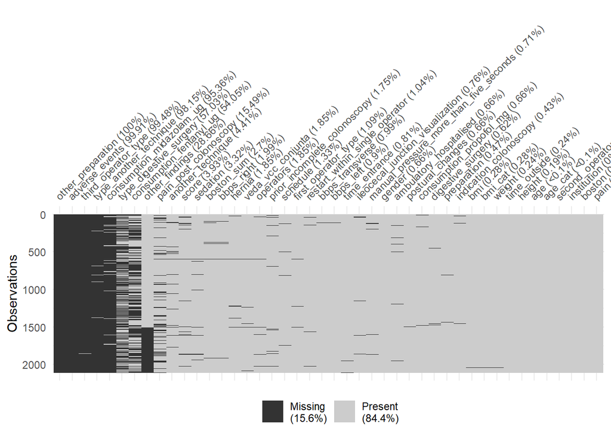

```r
#Evaluacion de los datos faltantes

#subset para imputar, las variables pain y propofol las vamos a usar luego como outcome sec

vis_miss(db_total,sort=TRUE)
```

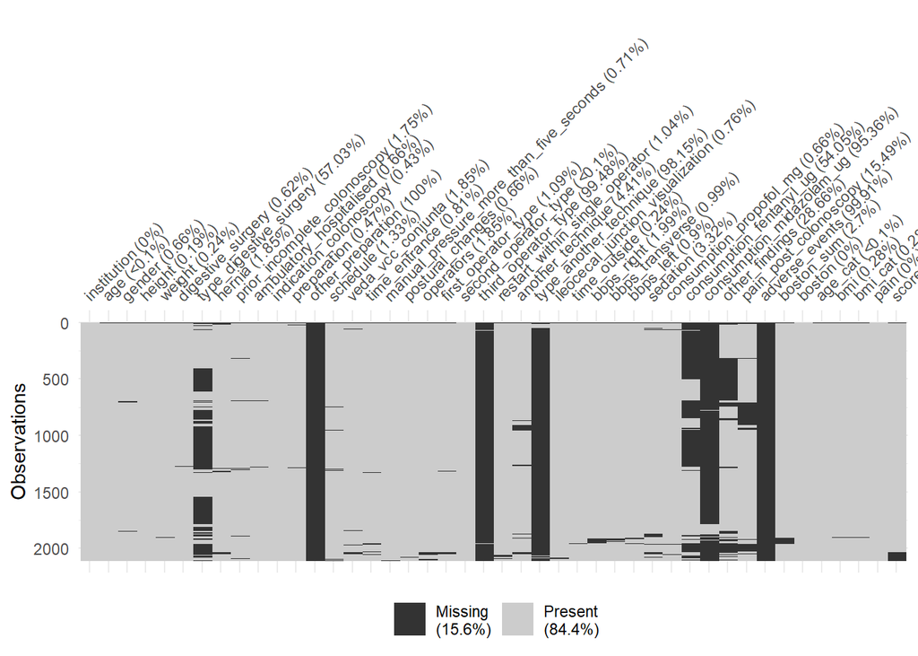

```r
vis_miss(db_total,cluster = TRUE)
```

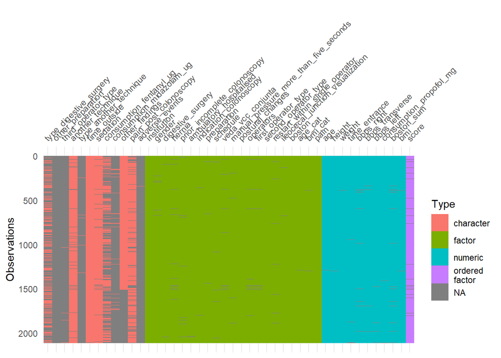

```r
vis_dat(db_total)
```

```r
apply(is.na(db_total),2,sum)
```

```
##                            institution                                    age
##                                      0                                      2
##                                 gender                                 height
##                                     14                                      4
##                                 weight                      digestive_surgery
##                                      5                                     13
##                 type_digestive_surgery                                 hernia
##                                   1204                                     39
##           prior_incomplete_colonoscopy                ambulatory_hospitalised
##                                     37                                     14
##                 indication_colonoscopy                            preparation
##                                      9                                     10
##                      other_preparation                               schedule
##                                   2111                                     28
##                      veda_vcc_conjunta                          time_entrance
##                                     39                                     17
## manual_pressure_more_than_five_seconds                       postural_changes
##                                     15                                     14
##                              operators                    first_operator_type
##                                     39                                     23
##                   second_operator_type                    third_operator_type
##                                      1                                   2100
##         restart_within_single_operator                      another_technique
##                                     22                                     93
##                 type_another_technique       ileocecal_junction_visualization
##                                   2072                                     16
##                           time_outside                             bbps_right
##                                      5                                     42
##                        bbps_transverse                              bbps_left
##                                     21                                     19
##                               sedation                consumption_propofol_mg
##                                     70                                     14
##                consumption_fentanyl_ug               consumption_midazolam_ug
##                                   1141                                   2013
##                         other_findings                  pain_post_colonoscopy
##                                    605                                    327
##                         adverse_events                             boston_sum
##                                   2109                                     57
##                                 boston                                age_cat
##                                      0                                      2
##                                    bmi                                bmi_cat
##                                      6                                      6
##                                   pain                                  score
##                                      0                                     83
```

```r
sum(is.na(db_total))#cantidad de celdas vacias
```

```
## [1] 14461
```

```r
n_miss(db_total)#otra opcion
```

```
## [1] 14461
```

```r
n_case_miss(db_total)#cantidad de observaciones con algun dato faltante
```

```
## [1] 2111
```

```r
pct_miss_case(db_total)#proporcion de filas con algun dato faltante
```

```
## [1] 100
```

# 5 *Imputacion de datos faltantes*

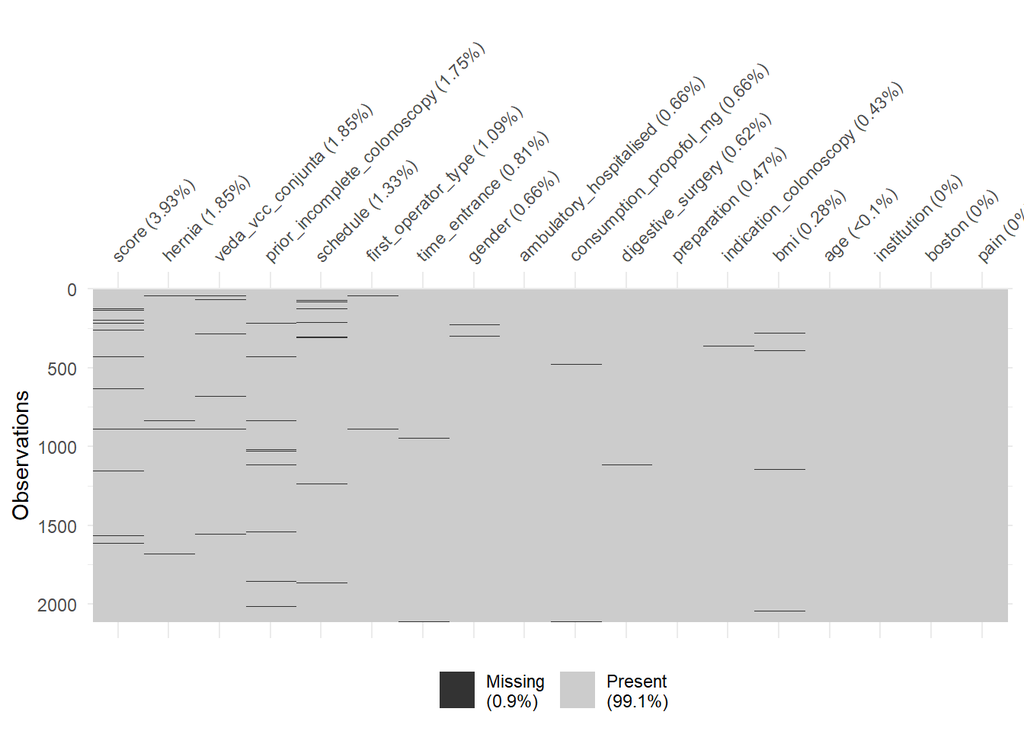

```r
#subset para imputar, las variables pain, sedacion y consumo de fentanilo las vamos a dejar para una 2da instancia como outcomes secundarios

db1<-subset(db_total,select=c(age,gender,bmi,digestive_surgery,prior_incomplete_colonoscopy,hernia,institution,ambulatory_hospitalised,preparation,indication_colonoscopy,schedule,veda_vcc_conjunta,time_entrance,first_operator_type,boston,consumption_propofol_mg,pain,score))

#Datos faltantes

vis_miss(db1,sort=TRUE)
```

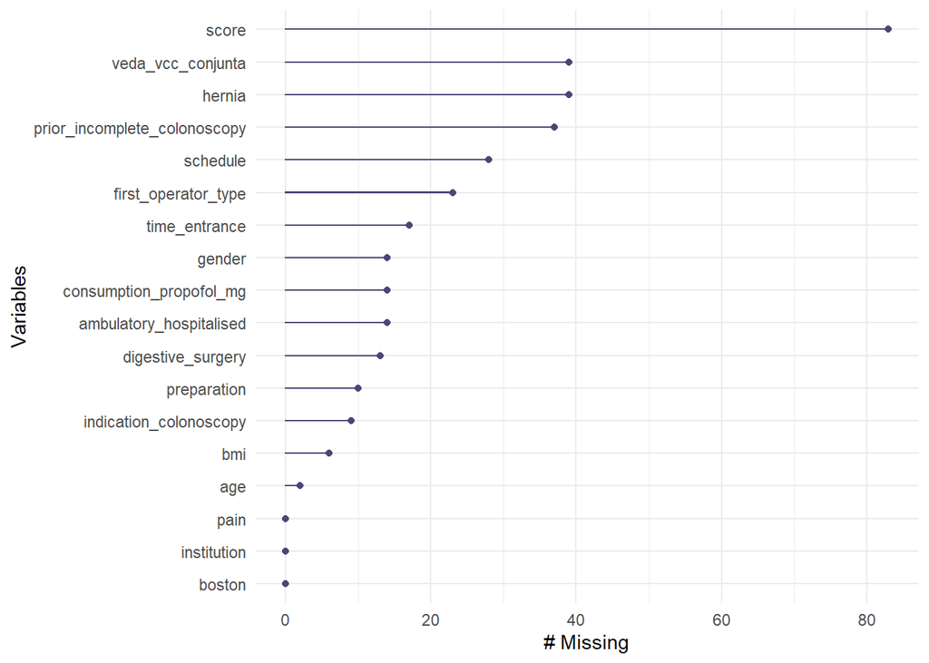

```r
gg_miss_var(db1)#1%
```

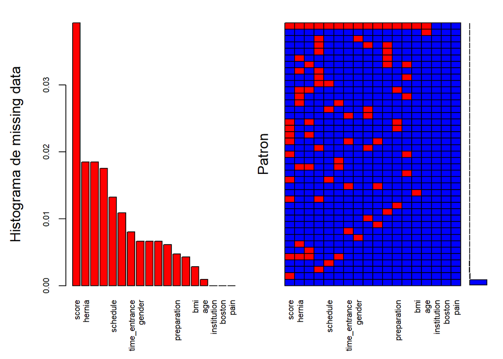

```
##
##  Variables sorted by number of missings:
##                      Variable        Count
##                         score 0.0393178588
##                        hernia 0.0184746566
##             veda_vcc_conjunta 0.0184746566
##  prior_incomplete_colonoscopy 0.0175272383
##                      schedule 0.0132638560
##           first_operator_type 0.0108953103
##                 time_entrance 0.0080530554
##                        gender 0.0066319280
##       ambulatory_hospitalised 0.0066319280
##       consumption_propofol_mg 0.0066319280
##             digestive_surgery 0.0061582189
##                   preparation 0.0047370914
##        indication_colonoscopy 0.0042633823
##                           bmi 0.0028422549
##                           age 0.0009474183
##                   institution 0.0000000000
##                        boston 0.0000000000
##                          pain 0.0000000000
```

```r
aggr_plot <- aggr(db1, col=c('blue','red'), numbers=TRUE, sortVars=TRUE, labels=names(db1), cex.axis=.7, gap=3, ylab=c("Histograma de missing data","Patron"))
```

```r
#veamos proporcion real de faltantes

db1_miss <- na.omit(db1)
n_inicial <- nrow(db1)
n_final <- nrow(db1_miss)
(n_inicial- n_final)/n_inicial# 11%
```

```
## [1] 0.1141639
```

```r
#imputacion multiple

base_imputada <- mice (db1, m = 10,defaultMethod = c("pmm","logreg", "polyreg", "polr"), maxit = 5,printFlag = F, seed = 123)
summary(base_imputada)#genero 10 muestras con imputaciones posibles
```

```
## Class: mids
## Number of multiple imputations:  10
## Imputation methods:
##                          age                       gender
##                        "pmm"                     "logreg"
##                          bmi            digestive_surgery
##                        "pmm"                     "logreg"
## prior_incomplete_colonoscopy                       hernia
##                     "logreg"                     "logreg"
##                  institution      ambulatory_hospitalised
##                           ""                     "logreg"
##                  preparation       indication_colonoscopy
##                    "polyreg"                    "polyreg"
##                     schedule            veda_vcc_conjunta
##                     "logreg"                     "logreg"
##                time_entrance          first_operator_type
##                        "pmm"                     "logreg"
##                       boston      consumption_propofol_mg
##                           ""                        "pmm"
##                         pain                        score
##                           ""                       "polr"
## PredictorMatrix:
##                              age gender bmi digestive_surgery
## age                            0      1   1                 1
## gender                         1      0   1                 1
## bmi                            1      1   0                 1
## digestive_surgery              1      1   1                 0
## prior_incomplete_colonoscopy   1      1   1                 1
## hernia                         1      1   1                 1
##                              prior_incomplete_colonoscopy hernia institution
## age                                                     1      1           1
## gender                                                  1      1           1
## bmi                                                     1      1           1
## digestive_surgery                                       1      1           1
## prior_incomplete_colonoscopy                            0      1           1
## hernia                                                  1      0           1
##                              ambulatory_hospitalised preparation
## age                                                1           1
## gender                                             1           1
## bmi                                                1           1
```

[output cut: 9 more lines]

```
## hernia                                            1        1                 1
##                              time_entrance first_operator_type boston
## age                                      1                   1      1
## gender                                   1                   1      1
## bmi                                      1                   1      1
## digestive_surgery                        1                   1      1
## prior_incomplete_colonoscopy             1                   1      1
## hernia                                   1                   1      1
##                              consumption_propofol_mg pain score
## age                                                1    1     1
## gender                                             1    1     1
## bmi                                                1    1     1
## digestive_surgery                                  1    1     1
## prior_incomplete_colonoscopy                       1    1     1
## hernia                                             1    1     1
```

```r
base_imputada$imp$score#muestra las observaciones q se imputaron
```

```
##      1 2 3 4 5 6 7 8 9 10
## 31   1 2 1 2 2 1 1 1 1  1
## 37   2 2 4 2 2 3 1 2 3  2
## 38   1 2 1 4 2 4 4 2 3  1
## 64   1 2 4 3 1 4 2 1 3  2
## 66   4 4 3 4 3 4 4 3 4  4
## 98   2 1 2 1 1 3 1 1 1  2
## 115  2 1 2 4 1 1 2 3 3  2
## 121  1 1 1 1 1 1 1 3 2  1
## 125  1 1 1 1 1 2 1 1 1  2
## 131  2 1 2 2 1 4 3 1 1  1
## 140  3 1 4 2 2 1 1 2 3  1
## 154  1 1 3 2 1 2 3 4 1  2
## 194  4 4 1 1 3 3 2 4 3  3
## 213  2 1 2 1 1 2 1 2 1  2
```

[output cut: 69 more lines]

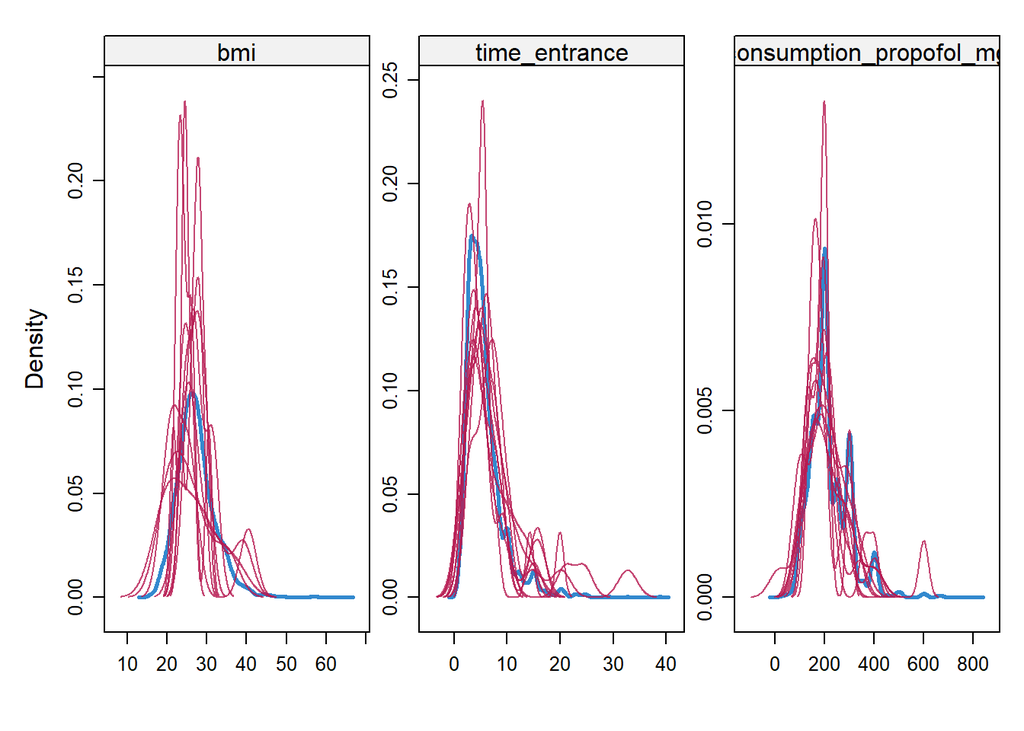

```r
densityplot(base_imputada)
```

```r
fit_ordinal <- with(base_imputada,clm(score~age+gender+bmi+prior_incomplete_colonoscopy+ambulatory_hospitalised+preparation+schedule+veda_vcc_conjunta+time_entrance+first_operator_type+boston, link = "logit"))
print(pool(fit_ordinal))
```

```
## Class: mipo    m = 10
##                                    term  m     estimate         ubar
## 1                                   1|2 10 -0.816407191 1.127052e-01
## 2                                   2|3 10  0.636148621 1.121322e-01
## 3                                   3|4 10  1.582140213 1.131368e-01
## 4                                   4|5 10  3.184541078 1.221454e-01
## 5                                   age 10  0.009687813 9.747513e-06
## 6                           gendermujer 10  0.543399788 7.083237e-03
## 7                                   bmi 10 -0.014863372 7.138722e-05
## 8        prior_incomplete_colonoscopysi 10  0.766980961 5.668907e-02
## 9  ambulatory_hospitalisedhospitalizado 10 -0.691735159 1.859350e-01
## 10                  preparationsulfodom 10  0.462809617 1.633565e-02
## 11                  preparationfosfodom 10  0.501435918 1.664872e-02
## 12                      preparationotra 10 -0.893729977 1.659131e-02
## 13                        scheduletarde 10  0.114852888 7.690895e-03
```

[output cut: 22 more lines]

```r
summary(pool(fit_ordinal))
```

```
##                                    term     estimate   std.error  statistic
## 1                                   1|2 -0.816407191 0.343590564 -2.3761048
## 2                                   2|3  0.636148621 0.343438544  1.8522924
## 3                                   3|4  1.582140213 0.344903433  4.5871976
## 4                                   4|5  3.184541078 0.358216739  8.8899840
## 5                                   age  0.009687813 0.003222594  3.0062152
## 6                           gendermujer  0.543399788 0.086134748  6.3087174
## 7                                   bmi -0.014863372 0.008597726 -1.7287562
## 8        prior_incomplete_colonoscopysi  0.766980961 0.242530354  3.1624122
## 9  ambulatory_hospitalisedhospitalizado -0.691735159 0.445586244 -1.5524159
## 10                  preparationsulfodom  0.462809617 0.129697476  3.5683780
## 11                  preparationfosfodom  0.501435918 0.130940398  3.8294974
## 12                      preparationotra -0.893729977 0.130486955 -6.8491902
## 13                        scheduletarde  0.114852888 0.089835645  1.2784779
## 14                  veda_vcc_conjuntasi -0.026364449 0.085299055 -0.3090825
```

[output cut: 21 more lines]

```r
fit_ordinal$analyses #genero 10 modelos con las bases imputadas
```

```
## [[1]]
## formula:
## score ~ age + gender + bmi + prior_incomplete_colonoscopy + ambulatory_hospitalised + preparation + schedule + veda_vcc_conjunta + time_entrance + first_operator_type + boston
##
##  link  threshold nobs logLik   AIC     niter max.grad cond.H
##  logit flexible  2111 -2742.01 5518.01 5(0)  2.52e-08 1.2e+06
##
## Coefficients:
##                                  age                          gendermujer
##                             0.009811                             0.567388
##                                  bmi       prior_incomplete_colonoscopysi
##                            -0.013361                             0.800790
## ambulatory_hospitalisedhospitalizado                  preparationsulfodom
##                            -0.709474                             0.486454
##                  preparationfosfodom                      preparationotra
##                             0.514967                            -0.880880
##                        scheduletarde                  veda_vcc_conjuntasi
##                             0.141907                            -0.029486
##                        time_entrance           first_operator_typeexperto
##                             0.076982                            -0.993198
##                      bostonExcelente
##                            -0.566596
##
## Threshold coefficients:
##     1|2     2|3     3|4     4|5
## -0.7333  0.7123  1.6479  3.2505
##
## [[2]]
## formula:
## score ~ age + gender + bmi + prior_incomplete_colonoscopy + ambulatory_hospitalised + preparation + schedule + veda_vcc_conjunta + time_entrance + first_operator_type + boston
##
##  link  threshold nobs logLik   AIC     niter max.grad cond.H
##  logit flexible  2111 -2745.17 5524.35 5(0)  4.37e-08 1.2e+06
##
## Coefficients:
##                                  age                          gendermujer
##                             0.009022                             0.518357
##                                  bmi       prior_incomplete_colonoscopysi
##                            -0.017535                             0.811410
## ambulatory_hospitalisedhospitalizado                  preparationsulfodom
```

[output cut: 214 more lines]

```
##                             -0.01290                              0.75902
## ambulatory_hospitalisedhospitalizado                  preparationsulfodom
##                             -0.61312                              0.46995
##                  preparationfosfodom                      preparationotra
##                              0.51087                             -0.89939
##                        scheduletarde                  veda_vcc_conjuntasi
##                              0.12410                             -0.03795
##                        time_entrance           first_operator_typeexperto
##                              0.07725                             -1.04624
##                      bostonExcelente
##                             -0.56755
##
## Threshold coefficients:
##     1|2     2|3     3|4     4|5
## -0.7750  0.6917  1.6335  3.2372
```

```r
fit_ordinal$analyses[[5]]# podemos elegir uno y trabajar con ese
```

```
## formula:
## score ~ age + gender + bmi + prior_incomplete_colonoscopy + ambulatory_hospitalised + preparation + schedule + veda_vcc_conjunta + time_entrance + first_operator_type + boston
##
##  link  threshold nobs logLik   AIC     niter max.grad cond.H
##  logit flexible  2111 -2722.08 5478.16 5(0)  2.15e-08 1.2e+06
##
## Coefficients:
##                                  age                          gendermujer
##                             0.009206                             0.556520
##                                  bmi       prior_incomplete_colonoscopysi
##                            -0.015104                             0.763771
## ambulatory_hospitalisedhospitalizado                  preparationsulfodom
##                            -0.673731                             0.423299
##                  preparationfosfodom                      preparationotra
##                             0.502803                            -0.903106
##                        scheduletarde                  veda_vcc_conjuntasi
##                             0.110903                            -0.021087
##                        time_entrance           first_operator_typeexperto
##                             0.079425                            -1.029008
##                      bostonExcelente
##                            -0.551527
##
## Threshold coefficients:
##     1|2     2|3     3|4     4|5
## -0.8142  0.6327  1.5754  3.1667
```

# 6 *Eleccion de la base de datos para modelar*

```r
db_imp<-complete(base_imputada,4) # o tmb podemos elegir una de las 10 bases imputadas y armar el modelo
str(db_imp)
```

```
## 'data.frame':    2111 obs. of  18 variables:
##  $ age                         : num  60 73 42 67 67 73 35 70 47 54 ...
##  $ gender                      : Factor w/ 2 levels "hombre","mujer": 1 1 1 2 2 1 2 1 2 1 ...
##  $ bmi                         : num  27.8 23.6 24.2 31.9 24.6 ...
##  $ digestive_surgery           : Factor w/ 2 levels "no","si": 1 1 1 1 1 1 1 1 1 1 ...
##  $ prior_incomplete_colonoscopy: Factor w/ 2 levels "no","si": 1 1 1 1 1 1 1 1 1 1 ...
##  $ hernia                      : Factor w/ 2 levels "no","si": 1 2 1 1 1 1 1 1 1 1 ...
##  $ institution                 : Factor w/ 15 levels "","Centro de Estudios Digestivos",..: 11 11 11 11 10 10 10 10 10 10 ...
##  $ ambulatory_hospitalised     : Factor w/ 2 levels "ambulatorio",..: 1 1 1 1 1 1 1 1 1 1 ...
##  $ preparation                 : Factor w/ 4 levels "barex","sulfodom",..: 4 1 4 4 1 2 1 1 1 1 ...
##  $ indication_colonoscopy      : Factor w/ 4 levels "screening ccr",..: 1 3 2 1 3 3 3 1 1 1 ...
##  $ schedule                    : Factor w/ 2 levels "mañana","tarde": 1 1 1 1 2 2 2 2 2 2 ...
##  $ veda_vcc_conjunta           : Factor w/ 2 levels "no","si": 2 1 1 1 1 1 1 1 2 1 ...
##  $ time_entrance               : num  3.5 3.5 2 8 15.1 ...
##  $ first_operator_type         : Factor w/ 2 levels "junior","experto": 2 2 2 2 2 2 2 2 2 2 ...
##  $ boston                      : Factor w/ 2 levels "Bueno","Excelente": 2 2 2 2 2 2 2 1 2 1 ...
##  $ consumption_propofol_mg     : num  300 200 280 250 200 300 220 200 350 200 ...
##  $ pain                        : Factor w/ 3 levels "leve","moderado",..: 1 1 1 1 1 3 3 1 1 1 ...
##  $ score                       : Ord.factor w/ 5 levels "1"<"2"<"3"<"4"<..: 1 1 1 4 3 2 3 2 2 2 ...
```

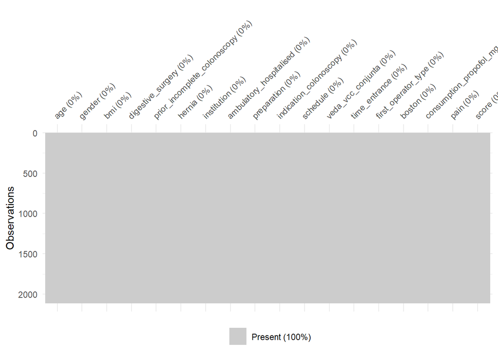

```r
vis_miss(db_imp,sort=TRUE)
```

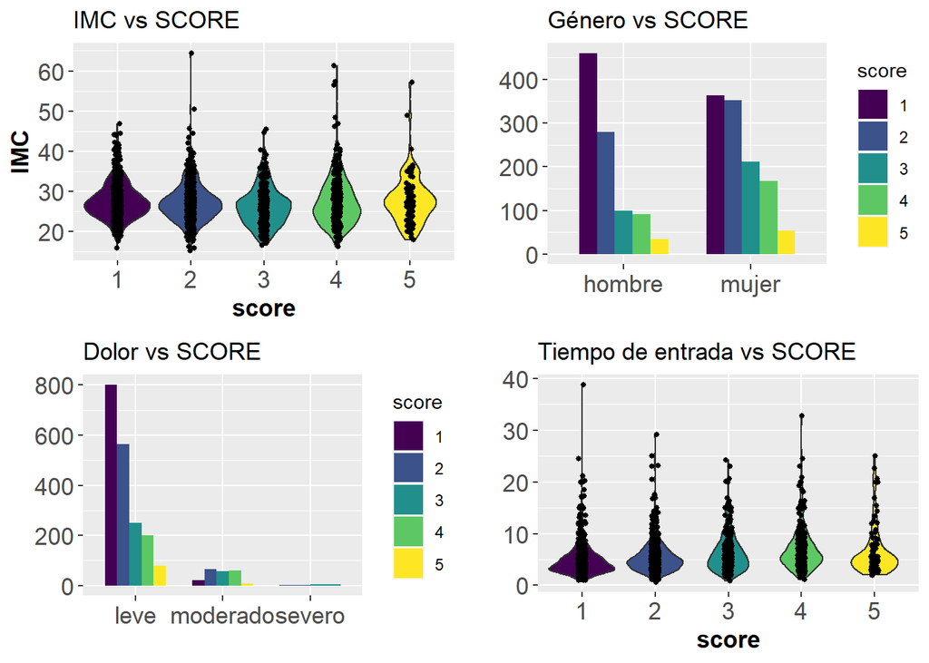

```r
p1<-ggplot(data = db_imp, mapping = aes(x=score, y=bmi))+
  geom_violin(mapping = aes(fill=score))+
  geom_jitter(size=1, position = position_jitter(width = 0.05))+labs(title = "IMC vs SCORE",y="IMC")+
  theme(legend.position="none",axis.title = element_text(size=13,face = "bold"),axis.text = element_text(size=13))

p2<-ggplot(db_imp, aes(gender))+
  geom_bar(aes(fill=score),position="dodge",width=0.7)+labs(title = "Género vs SCORE",x="",y="")+theme(axis.text = element_text(size=13))

p3<-ggplot(db_imp, aes(pain))+
  geom_bar(aes(fill=score),position="dodge",width=0.7)+labs(title = "Dolor vs SCORE",x="",y="")+theme(axis.text = element_text(size=13))

p4<-ggplot(data = db_imp, mapping = aes(x=score, y=time_entrance))+
  geom_violin(mapping = aes(fill=score))+
  geom_jitter(size=1, position = position_jitter(width = 0.05))+labs(title = "Tiempo de entrada vs SCORE",y="")+
  theme(legend.position="none",axis.title = element_text(size=13,face = "bold"),axis.text = element_text(size=13))

plot_grid(p1,p2,p3,p4)
```

```r
set.seed(123)

sample <- sample(1:2111)
train_db <- sort(sample(1:nrow(db_imp), size=floor(nrow(db_imp)*(2/3))))
test_db <- setdiff(1:nrow(db_imp), train_db)
datatrain <- db_imp[train_db,]
datatest <- db_imp[test_db,]
# Construct OF prediction rule using the training dataset (default
# perffunction = "probability" corresponding to the
# (negative) ranked probability score as performance function):

ordforres <- ordfor(depvar="score", data=datatrain, nsets=1000, ntreeperdiv=100,
ntreefinal=5000, perffunction = "equal", importance = c("rps", "accuracy"))

sort(ordforres$varimp, decreasing = TRUE)
```

```
##                  institution                  preparation
##                 2.317394e-02                 1.469876e-02
##                         pain                time_entrance
##                 1.014448e-02                 8.294402e-03
##                       boston      consumption_propofol_mg
##                 6.369444e-03                 5.772367e-03
##          first_operator_type                          bmi
##                 5.448366e-03                 5.024756e-03
##                       gender                          age
##                 3.064250e-03                 2.123310e-03
##                     schedule       indication_colonoscopy
##                 1.036556e-03                 9.171245e-04
## prior_incomplete_colonoscopy            veda_vcc_conjunta
##                 8.787676e-04                 8.414402e-04
##      ambulatory_hospitalised                       hernia
##                 2.222357e-04                 7.108103e-05
##            digestive_surgery
##                -9.974777e-05
```

[figure not shown]

```r
v<-as.vector(ordforres$varimp)
w<-(as.vector((colnames(db_imp[,-c(7,18)]))))#sacamos la var de rta y de ef aleatorios
DF<-cbind(w,v)
DF<-as.data.frame(DF)

DF<-DF %>% mutate(v=as.numeric(v),
              w=as.factor(w))

ggplot(DF, aes(x=reorder(w,v), y=v,fill=w))+
  geom_bar(stat="identity", position="dodge")+ coord_flip()+
  ylab("Variable Importance")+
  xlab("")+
  theme(legend.position = "none")
```

```r
ordforres$forestfinal
```

```
## Ranger result
##
## Call:
##  rangerordfor(dependent.variable.name = "ymetric", data = datait,      num.trees = ntreefinal, importance = ifelse(importanceinternal ==          "rps", "none", "permutation"), num.threads = num.threads,      borders = qnorm(bordersbest[-c(1, length(bordersbest))]),      mtry = mtry, min.node.siz…
##
## Type:                             Regression
## Number of trees:                  5000
## Sample size:                      1407
## Number of independent variables:  17
## Mtry:                             4
## Target node size:                 5
## Variable importance mode:         none
## Splitrule:                        variance
## OOB prediction error (MSE):       0.2639955
## R squared (OOB):                  0.198138
```

```r
#ECM del ordinal forest 0.26
```

```r
#Modelo: introducimos una variable de efectos aleatorios:institucion

model1 <- clmm(score~age+gender+bmi+digestive_surgery+prior_incomplete_colonoscopy+hernia+ambulatory_hospitalised+preparation+schedule+veda_vcc_conjunta+time_entrance+first_operator_type+boston+pain+consumption_propofol_mg + (1|institution),data=db_imp, Hess=T)

summary(model1)
```

```
## Cumulative Link Mixed Model fitted with the Laplace approximation
##
## formula:
## score ~ age + gender + bmi + digestive_surgery + prior_incomplete_colonoscopy +
##     hernia + ambulatory_hospitalised + preparation + schedule +
##     veda_vcc_conjunta + time_entrance + first_operator_type +
##     boston + pain + consumption_propofol_mg + (1 | institution)
## data:    db_imp
##
##  link  threshold nobs logLik   AIC     niter      max.grad cond.H
##  logit flexible  2111 -2630.19 5306.39 2966(8908) 6.02e-02 3.0e+06
##
## Random effects:
##  Groups      Name        Variance Std.Dev.
##  institution (Intercept) 0.7179   0.8473
## Number of groups:  institution 15
##
## Coefficients:
##                                        Estimate Std. Error z value Pr(>|z|)
## age                                   0.0105968  0.0032929   3.218 0.001290 **
## gendermujer                           0.5642618  0.0882917   6.391 1.65e-10 ***
## bmi                                  -0.0189089  0.0087236  -2.168 0.030193 *
## digestive_surgerysi                   0.0896264  0.0890721   1.006 0.314308
## prior_incomplete_colonoscopysi        0.5388540  0.2434102   2.214 0.026845 *
## herniasi                              0.5235816  0.2705529   1.935 0.052962 .
## ambulatory_hospitalisedhospitalizado -0.1863637  0.4366797  -0.427 0.669544
## preparationsulfodom                   0.2159312  0.1497043   1.442 0.149194
## preparationfosfodom                   0.1255666  0.2186189   0.574 0.565722
## preparationotra                      -0.2174610  0.1721974  -1.263 0.206640
## scheduletarde                         0.3453170  0.0981284   3.519 0.000433 ***
## veda_vcc_conjuntasi                   0.0573270  0.0876782   0.654 0.513219
## time_entrance                         0.0467090  0.0121136   3.856 0.000115 ***
## first_operator_typeexperto           -0.6303601  0.1492341  -4.224 2.40e-05 ***
## bostonExcelente                      -0.3731071  0.0978637  -3.813 0.000138 ***
## painmoderado                          0.7072724  0.1480344   4.778 1.77e-06 ***
## painsevero                            0.2935123  0.7044343   0.417 0.676924
## consumption_propofol_mg               0.0028458  0.0006159   4.621 3.82e-06 ***
## ---
## Signif. codes:  0 '***' 0.001 '**' 0.01 '*' 0.05 '.' 0.1 ' ' 1
##
## Threshold coefficients:
##     Estimate Std. Error z value
## 1|2   0.3746     0.4405   0.850
## 2|3   2.0089     0.4427   4.538
## 3|4   3.0338     0.4455   6.811
## 4|5   4.7055     0.4568  10.302
```

```r
exp(coef(model1))
```

```
##                                  1|2                                  2|3
##                            1.4543558                            7.4554220
##                                  3|4                                  4|5
##                           20.7760620                          110.5567899
##                                  age                          gendermujer
##                            1.0106532                            1.7581494
##                                  bmi                  digestive_surgerysi
##                            0.9812688                            1.0937656
##       prior_incomplete_colonoscopysi                             herniasi
##                            1.7140415                            1.6880629
## ambulatory_hospitalisedhospitalizado                  preparationsulfodom
##                            0.8299717                            1.2410170
##                  preparationfosfodom                      preparationotra
##                            1.1337906                            0.8045589
##                        scheduletarde                  veda_vcc_conjuntasi
##                            1.4124376                            1.0590020
##                        time_entrance           first_operator_typeexperto
##                            1.0478170                            0.5324001
##                      bostonExcelente                         painmoderado
##                            0.6885915                            2.0284508
##                           painsevero              consumption_propofol_mg
##                            1.3411297                            1.0028499
```

```r
exp(confint(model1))
```

```
##                                           2.5 %      97.5 %
## 1|2                                   0.6133562   3.4484870
## 2|3                                   3.1307529  17.7539777
## 3|4                                   8.6774588  49.7432208
## 4|5                                  45.1639081 270.6321111
## age                                   1.0041515   1.0171969
## gendermujer                           1.4787738   2.0903057
## bmi                                   0.9646336   0.9981907
## digestive_surgerysi                   0.9185566   1.3023945
## prior_incomplete_colonoscopysi        1.0637271   2.7619287
## herniasi                              0.9933301   2.8686901
## ambulatory_hospitalisedhospitalizado  0.3526638   1.9532852
## preparationsulfodom                   0.9254420   1.6642030
## preparationfosfodom                   0.7386592   1.7402900
## preparationotra                       0.5740942   1.1275416
## scheduletarde                         1.1653120   1.7119708
## veda_vcc_conjuntasi                   0.8917948   1.2575598
## time_entrance                         1.0232325   1.0729922
## first_operator_typeexperto            0.3973835   0.7132905
## bostonExcelente                       0.5684076   0.8341870
## painmoderado                          1.5176002   2.7112626
## painsevero                            0.3371749   5.3344093
## consumption_propofol_mg               1.0016400   1.0040611
```

```r
sf <- function(y){
c('y>=1' = qlogis(mean(y >= 1)),
'y>=2' = qlogis(mean(y >= 2)),
'y>=3' = qlogis(mean(y >= 3)),
'y>=4' = qlogis(mean(y >= 4)),
'y>=5' = qlogis(mean(y >= 5)))
}

supuestos_model1 <- with(db_imp,summary(as.numeric(score) ~ age+gender+bmi+digestive_surgery+prior_incomplete_colonoscopy+hernia+ambulatory_hospitalised+preparation+schedule+veda_vcc_conjunta+time_entrance+first_operator_type+boston+pain+consumption_propofol_mg, fun=sf))

supuestos_model1
```

```
## as.numeric(score)      N= 2111
##
## +----------------------------+-------------+----+----+-----------+----------+----------+---------+
## |                            |             |   N|y>=1|       y>=2|      y>=3|      y>=4|     y>=5|
## +----------------------------+-------------+----+----+-----------+----------+----------+---------+
## |                         age|     [18, 50)| 532| Inf| 0.35713146|-0.9255195|-1.8870696|-3.610918|
## |                            |     [50, 59)| 538| Inf| 0.40701430|-0.9046099|-1.7302342|-2.902206|
## |                            |     [59, 69)| 527| Inf| 0.27883246|-0.9403239|-1.5274429|-3.463781|
## |                            |     [69,101]| 514| Inf| 0.77603484|-0.4265869|-1.4083271|-2.816853|
## +----------------------------+-------------+----+----+-----------+----------+----------+---------+
## |                      gender|       hombre| 965| Inf| 0.09333194|-1.1847629|-1.8959288|-3.309899|
## |                            |        mujer|1146| Inf| 0.76872986|-0.5061745|-1.4372467|-3.026390|
## +----------------------------+-------------+----+----+-----------+----------+----------+---------+
## |                         bmi|  [15.2,24.2)| 543| Inf| 0.76870759|-0.4688067|-1.4640721|-3.164708|
## |                            |  [24.2,26.8)| 515| Inf| 0.31719613|-0.9951152|-1.8169037|-3.506558|
## |                            |  [26.8,29.7)| 527| Inf| 0.30985593|-0.9974163|-1.9095425|-2.999724|
## |                            |  [29.7,64.5]| 526| Inf| 0.40071451|-0.7653286|-1.4006144|-2.997730|
## +----------------------------+-------------+----+----+-----------+----------+----------+---------+
## |           digestive_surgery|           no|1199| Inf| 0.36945014|-0.9391723|-1.8422903|-3.392614|
## |                            |           si| 912| Inf| 0.55315999|-0.6151856|-1.3890378|-2.890372|
## +----------------------------+-------------+----+----+-----------+----------+----------+---------+
## |prior_incomplete_colonoscopy|           no|2047| Inf| 0.43158904|-0.8266786|-1.6674165|-3.215325|
## |                            |           si|  64| Inf| 1.01693426| 0.1251631|-0.7166777|-1.945910|
## +----------------------------+-------------+----+----+-----------+----------+----------+---------+
## |                      hernia|           no|2063| Inf| 0.43219817|-0.8195215|-1.6513196|-3.147190|
## |                            |           si|  48| Inf| 1.21302264| 0.1670541|-0.8873032|-3.135494|
## +----------------------------+-------------+----+----+-----------+----------+----------+---------+
## |     ambulatory_hospitalised|  ambulatorio|2087| Inf| 0.45725272|-0.7911071|-1.6296991|-3.159251|
## |                            |hospitalizado|  24| Inf|-0.33647224|-1.0986123|-1.6094379|-2.397895|
## +----------------------------+-------------+----+----+-----------+----------+----------+---------+
## |                 preparation|        barex|1227| Inf| 0.54619277|-0.7449467|-1.7033040|-3.499030|
## |                            |     sulfodom| 257| Inf| 1.66170634|-0.1168643|-1.0423315|-2.780888|
## |                            |     fosfodom| 267| Inf| 0.65962449|-0.5449312|-1.1543229|-2.270062|
## |                            |         otra| 360| Inf|-0.70567344|-1.9977017|-2.5530445|-3.457177|
## +----------------------------+-------------+----+----+-----------+----------+----------+---------+
## |                    schedule|       mañana|1384| Inf| 0.44658336|-0.6715481|-1.5071713|-3.129479|
## |                            |        tarde| 727| Inf| 0.45037766|-1.0461115|-1.8950125|-3.180923|
## +----------------------------+-------------+----+----+-----------+----------+----------+---------+
## |           veda_vcc_conjunta|           no|1187| Inf| 0.48261690|-0.6805367|-1.7349315|-3.211019|
## |                            |           si| 924| Inf| 0.40366168|-0.9483301|-1.5040774|-3.069753|
```

[output cut: 8 more lines]

```
## +----------------------------+-------------+----+----+-----------+----------+----------+---------+
## |                      boston|        Bueno| 904| Inf| 0.95612419|-0.4082314|-1.1768477|-2.493325|
## |                            |    Excelente|1207| Inf| 0.10448601|-1.1241834|-2.0887961|-4.190496|
## +----------------------------+-------------+----+----+-----------+----------+----------+---------+
## |                        pain|         leve|1896| Inf| 0.31264870|-0.9441477|-1.7529196|-3.122365|
## |                            |     moderado| 210| Inf| 2.14539951| 0.3266842|-0.7801586|-3.367296|
## |                            |       severo|   5| Inf|        Inf| 1.3862944|      -Inf|     -Inf|
## +----------------------------+-------------+----+----+-----------+----------+----------+---------+
## |     consumption_propofol_mg|    [ 15,162)| 540| Inf| 0.54654371|-0.8561318|-1.6637499|-2.833213|
## |                            |    [162,202)| 773| Inf| 0.54338825|-0.9217305|-1.8503278|-3.175362|
## |                            |    [202,260)| 282| Inf| 0.15634607|-0.9614112|-1.4868356|-3.533687|
## |                            |    [260,800]| 516| Inf| 0.36845364|-0.4737844|-1.3887186|-3.320228|
## +----------------------------+-------------+----+----+-----------+----------+----------+---------+
## |                     Overall|             |2111| Inf| 0.44788971|-0.7943896|-1.6294672|-3.146923|
## +----------------------------+-------------+----+----+-----------+----------+----------+---------+
```

```r
supuestos_model1[, 6] <- supuestos_model1[, 6] - supuestos_model1[, 5]
supuestos_model1[, 5] <- supuestos_model1[, 5] - supuestos_model1[, 4]
supuestos_model1[, 4] <- supuestos_model1[, 4] - supuestos_model1[, 3]
supuestos_model1[, 3] <- supuestos_model1[, 3] - supuestos_model1[, 3]
supuestos_model1
```

```
## as.numeric(score)      N= 2111
##
## +----------------------------+-------------+----+----+----+----------+----------+----------+
## |                            |             |   N|y>=1|y>=2|      y>=3|      y>=4|      y>=5|
## +----------------------------+-------------+----+----+----+----------+----------+----------+
## |                         age|     [18, 50)| 532| Inf|   0|-1.2826510|-0.9615501|-1.7238483|
## |                            |     [50, 59)| 538| Inf|   0|-1.3116242|-0.8256244|-1.1719720|
## |                            |     [59, 69)| 527| Inf|   0|-1.2191564|-0.5871190|-1.9363379|
## |                            |     [69,101]| 514| Inf|   0|-1.2026218|-0.9817401|-1.4085260|
## +----------------------------+-------------+----+----+----+----------+----------+----------+
## |                      gender|       hombre| 965| Inf|   0|-1.2780949|-0.7111659|-1.4139700|
## |                            |        mujer|1146| Inf|   0|-1.2749043|-0.9310722|-1.5891429|
## +----------------------------+-------------+----+----+----+----------+----------+----------+
## |                         bmi|  [15.2,24.2)| 543| Inf|   0|-1.2375143|-0.9952653|-1.7006355|
## |                            |  [24.2,26.8)| 515| Inf|   0|-1.3123113|-0.8217884|-1.6896542|
## |                            |  [26.8,29.7)| 527| Inf|   0|-1.3072722|-0.9121262|-1.0901818|
## |                            |  [29.7,64.5]| 526| Inf|   0|-1.1660431|-0.6352858|-1.5971159|
## +----------------------------+-------------+----+----+----+----------+----------+----------+
## |           digestive_surgery|           no|1199| Inf|   0|-1.3086225|-0.9031179|-1.5503234|
## |                            |           si| 912| Inf|   0|-1.1683456|-0.7738522|-1.5013339|
## +----------------------------+-------------+----+----+----+----------+----------+----------+
## |prior_incomplete_colonoscopy|           no|2047| Inf|   0|-1.2582676|-0.8407379|-1.5479087|
## |                            |           si|  64| Inf|   0|-0.8917711|-0.8418408|-1.2292325|
## +----------------------------+-------------+----+----+----+----------+----------+----------+
## |                      hernia|           no|2063| Inf|   0|-1.2517197|-0.8317981|-1.4958707|
## |                            |           si|  48| Inf|   0|-1.0459686|-1.0543573|-2.2481910|
## +----------------------------+-------------+----+----+----+----------+----------+----------+
## |     ambulatory_hospitalised|  ambulatorio|2087| Inf|   0|-1.2483598|-0.8385920|-1.5295516|
## |                            |hospitalizado|  24| Inf|   0|-0.7621401|-0.5108256|-0.7884574|
## +----------------------------+-------------+----+----+----+----------+----------+----------+
## |                 preparation|        barex|1227| Inf|   0|-1.2911394|-0.9583574|-1.7957256|
## |                            |     sulfodom| 257| Inf|   0|-1.7785707|-0.9254671|-1.7385561|
## |                            |     fosfodom| 267| Inf|   0|-1.2045557|-0.6093917|-1.1157390|
## |                            |         otra| 360| Inf|   0|-1.2920282|-0.5553428|-0.9041322|
## +----------------------------+-------------+----+----+----+----------+----------+----------+
## |                    schedule|       mañana|1384| Inf|   0|-1.1181314|-0.8356233|-1.6223078|
## |                            |        tarde| 727| Inf|   0|-1.4964892|-0.8489010|-1.2859108|
## +----------------------------+-------------+----+----+----+----------+----------+----------+
## |           veda_vcc_conjunta|           no|1187| Inf|   0|-1.1631536|-1.0543948|-1.4760875|
## |                            |           si| 924| Inf|   0|-1.3519918|-0.5557473|-1.5656757|
```

[output cut: 8 more lines]

```
## +----------------------------+-------------+----+----+----+----------+----------+----------+
## |                      boston|        Bueno| 904| Inf|   0|-1.3643556|-0.7686163|-1.3164776|
## |                            |    Excelente|1207| Inf|   0|-1.2286695|-0.9646127|-2.1017000|
## +----------------------------+-------------+----+----+----+----------+----------+----------+
## |                        pain|         leve|1896| Inf|   0|-1.2567964|-0.8087719|-1.3694453|
## |                            |     moderado| 210| Inf|   0|-1.8187153|-1.1068428|-2.5871373|
## |                            |       severo|   5| Inf|    |      -Inf|      -Inf|          |
## +----------------------------+-------------+----+----+----+----------+----------+----------+
## |     consumption_propofol_mg|    [ 15,162)| 540| Inf|   0|-1.4026755|-0.8076181|-1.1694634|
## |                            |    [162,202)| 773| Inf|   0|-1.4651187|-0.9285974|-1.3250342|
## |                            |    [202,260)| 282| Inf|   0|-1.1177572|-0.5254244|-2.0468510|
## |                            |    [260,800]| 516| Inf|   0|-0.8422380|-0.9149343|-1.9315097|
## +----------------------------+-------------+----+----+----+----------+----------+----------+
## |                     Overall|             |2111| Inf|   0|-1.2422793|-0.8350776|-1.5174557|
## +----------------------------+-------------+----+----+----+----------+----------+----------+
```

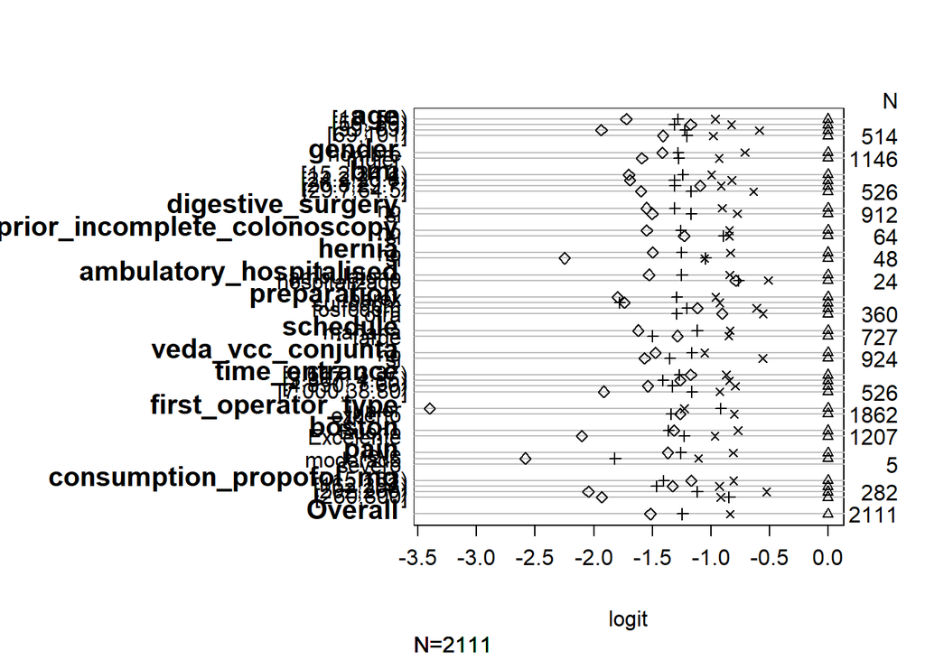

```r
plot(supuestos_model1, which=1:5,pch=1:5,xlab='logit', main=' ', xlim=range(supuestos_model1[,3:6],finite=T))
```

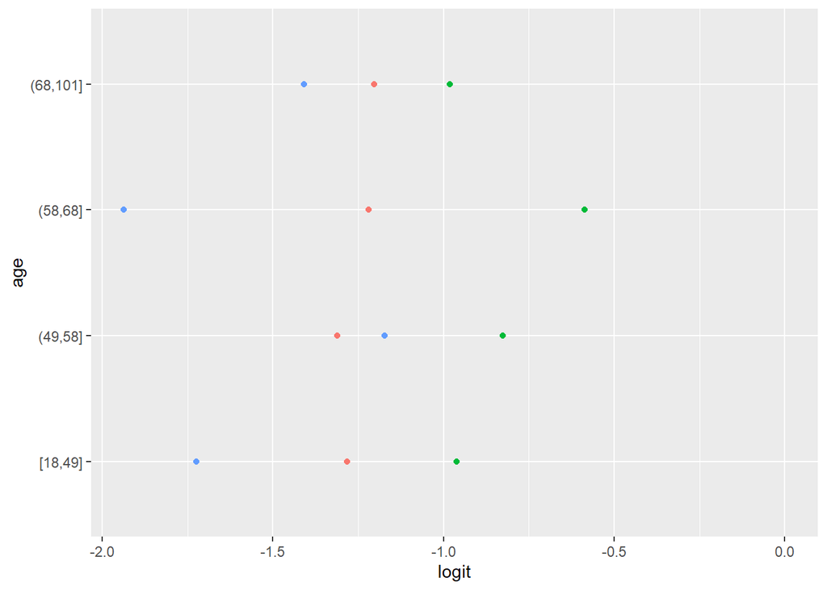

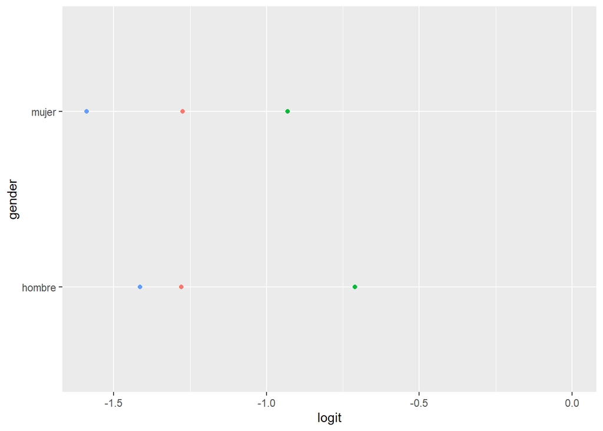

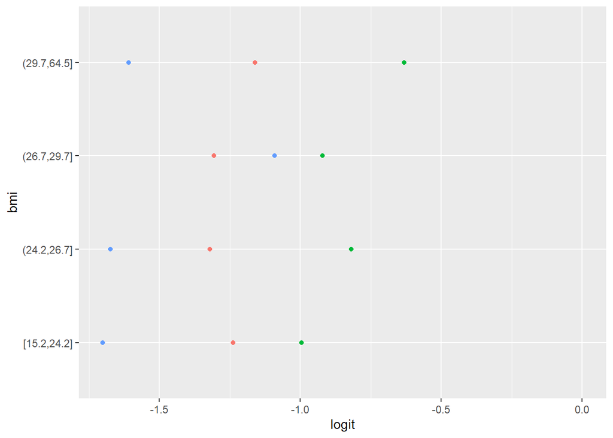

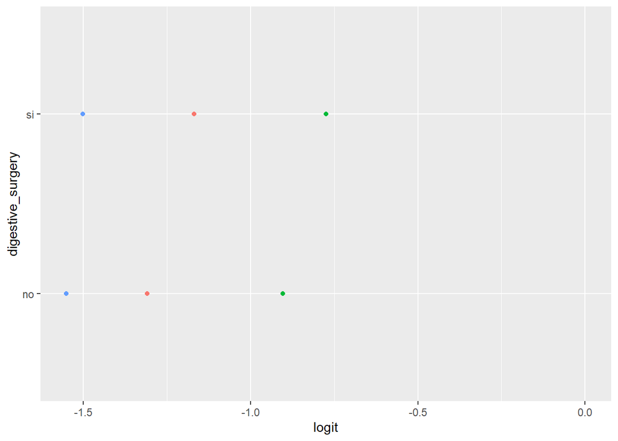

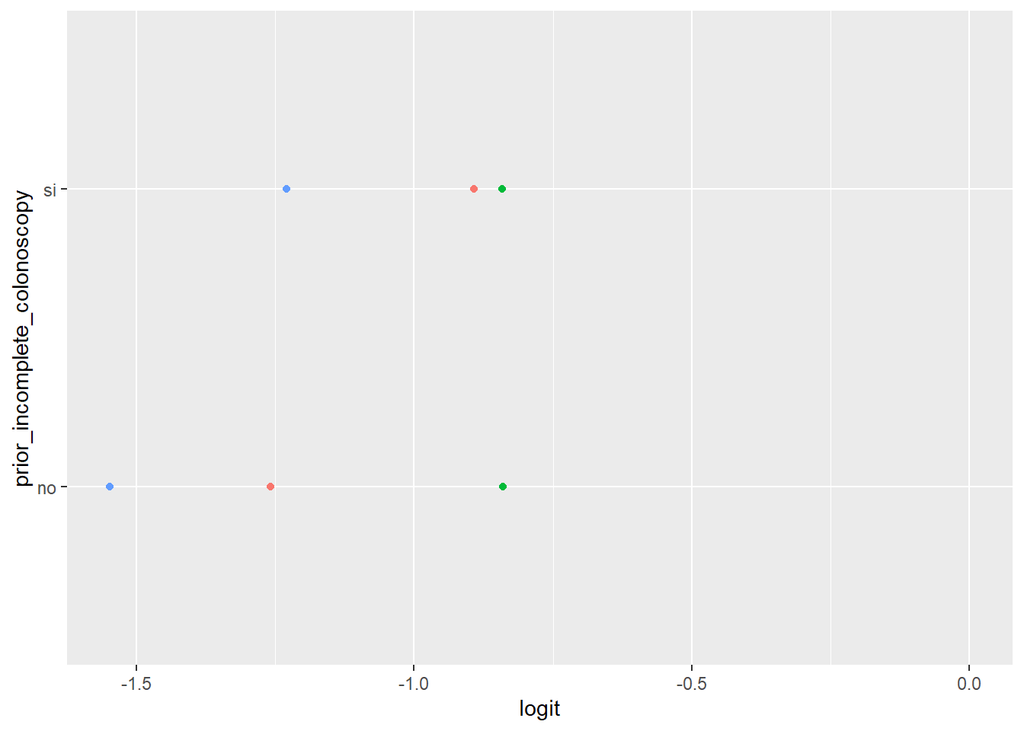

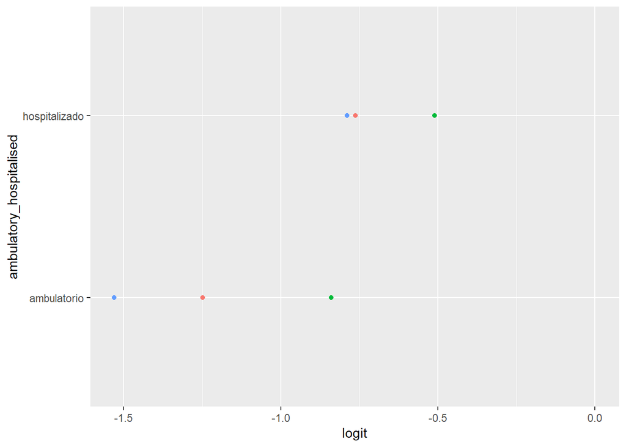

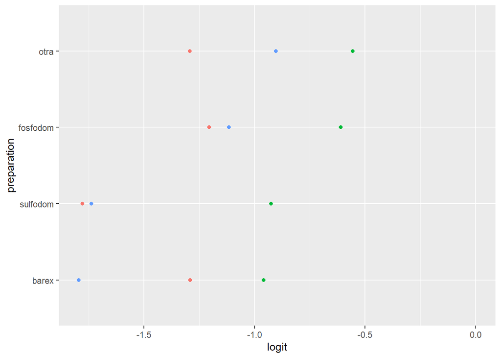

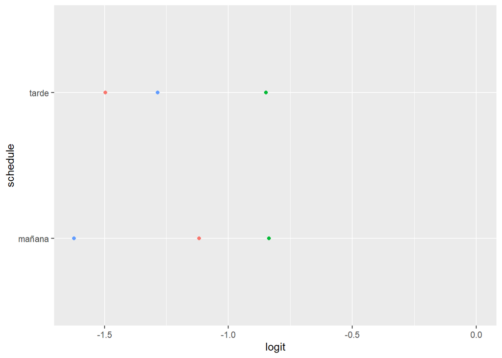

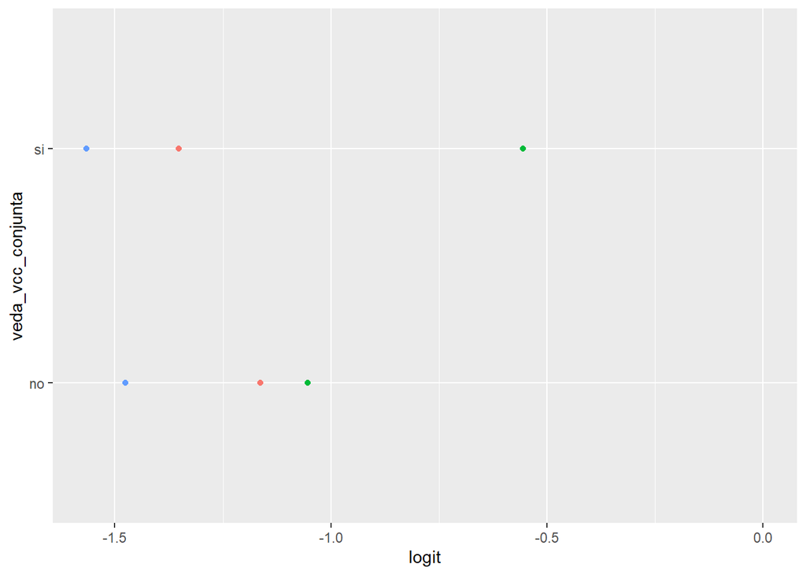

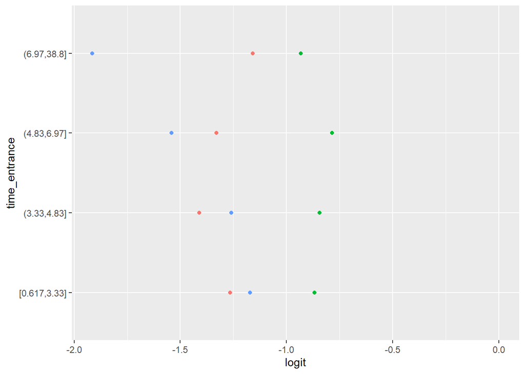

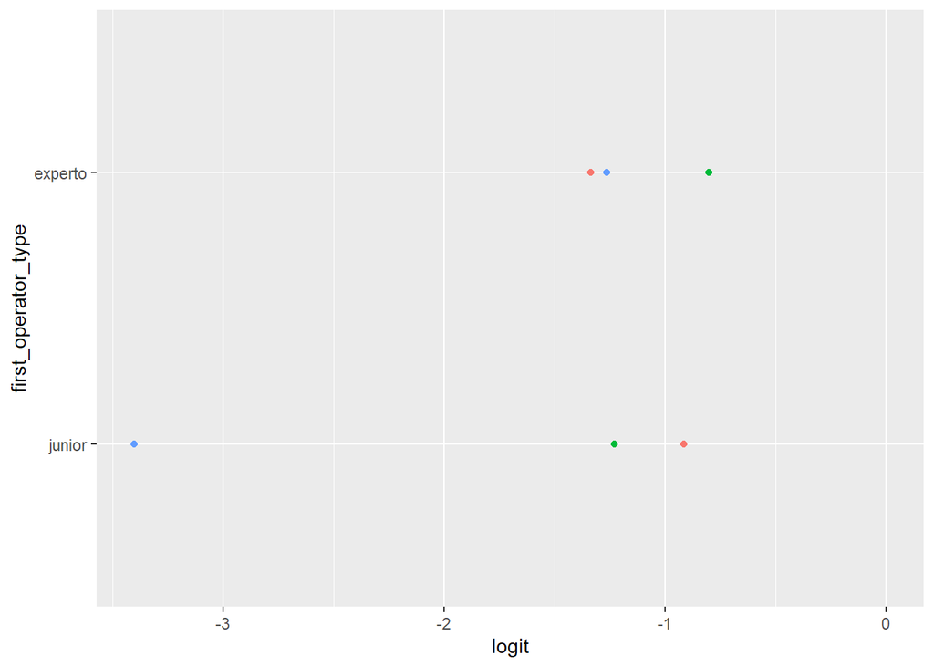

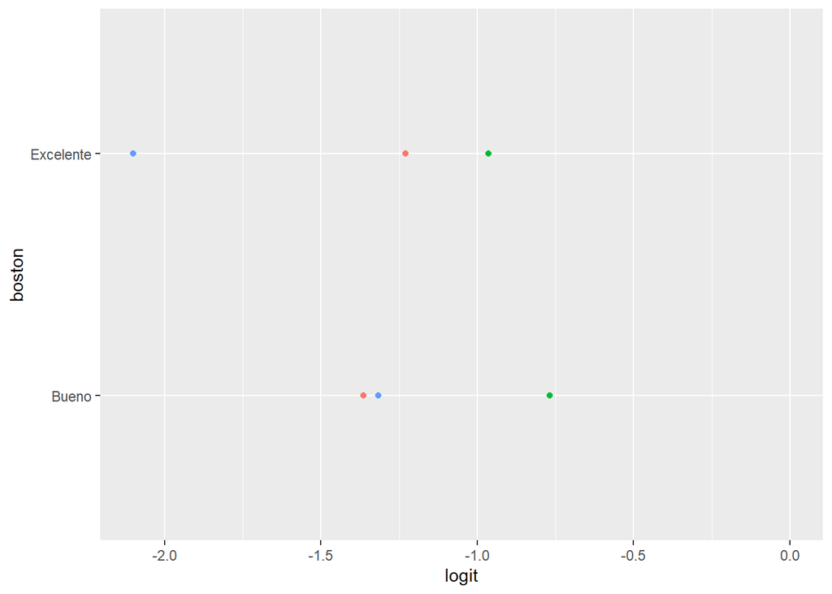

```r
#hace un grafico por variable, otra forma de chequear supuestos
plot(pomcheck(score~age+gender+bmi+digestive_surgery+prior_incomplete_colonoscopy+ambulatory_hospitalised+preparation+schedule+veda_vcc_conjunta+time_entrance+first_operator_type+boston, data=db_imp[,-7]))
```

Vemos otro modelo (2) sacando las variables VEDA/vcc conjunta y preparation segun ordinalforest

```r
model2 <- clmm(score~age+gender+bmi+digestive_surgery+prior_incomplete_colonoscopy+hernia+ambulatory_hospitalised+ schedule +time_entrance+first_operator_type+boston+pain+consumption_propofol_mg + (1|institution),data=db_imp, Hess=T )

summary(model2)
```

```
## Cumulative Link Mixed Model fitted with the Laplace approximation
##
## formula:
## score ~ age + gender + bmi + digestive_surgery + prior_incomplete_colonoscopy +
##     hernia + ambulatory_hospitalised + schedule + time_entrance +
##     first_operator_type + boston + pain + consumption_propofol_mg +
##     (1 | institution)
## data:    db_imp
##
##  link  threshold nobs logLik   AIC     niter      max.grad cond.H
##  logit flexible  2111 -2632.69 5303.39 2293(6891) 1.31e-01 2.9e+06
##
## Random effects:
##  Groups      Name        Variance Std.Dev.
##  institution (Intercept) 0.8078   0.8988
## Number of groups:  institution 15
##
## Coefficients:
##                                        Estimate Std. Error z value Pr(>|z|)
## age                                   0.0109266  0.0032651   3.346 0.000819 ***
## gendermujer                           0.5777703  0.0878123   6.580 4.72e-11 ***
## bmi                                  -0.0187299  0.0087018  -2.152 0.031365 *
## digestive_surgerysi                   0.0858313  0.0889481   0.965 0.334565
## prior_incomplete_colonoscopysi        0.5220291  0.2427858   2.150 0.031542 *
## herniasi                              0.5344718  0.2705275   1.976 0.048193 *
## ambulatory_hospitalisedhospitalizado -0.1411367  0.4366008  -0.323 0.746496
## scheduletarde                         0.3324472  0.0978753   3.397 0.000682 ***
## time_entrance                         0.0468492  0.0121241   3.864 0.000111 ***
## first_operator_typeexperto           -0.6498313  0.1470056  -4.420 9.85e-06 ***
## bostonExcelente                      -0.3835957  0.0976899  -3.927 8.61e-05 ***
## painmoderado                          0.6755501  0.1461668   4.622 3.80e-06 ***
## painsevero                            0.3143450  0.7013534   0.448 0.654011
## consumption_propofol_mg               0.0028905  0.0006155   4.696 2.65e-06 ***
## ---
## Signif. codes:  0 '***' 0.001 '**' 0.01 '*' 0.05 '.' 0.1 ' ' 1
##
## Threshold coefficients:
##     Estimate Std. Error z value
## 1|2   0.3425     0.4390   0.780
## 2|3   1.9744     0.4411   4.476
## 3|4   2.9981     0.4437   6.757
## 4|5   4.6699     0.4549  10.266
```

```r
exp(confint(model2))
```

```
##                                           2.5 %      97.5 %
## 1|2                                   0.5957967   3.3295614
## 2|3                                   3.0341101  17.0960921
## 3|4                                   8.4021180  47.8313237
## 4|5                                  43.7450025 260.2063735
## age                                   1.0045373   1.0174771
## gendermujer                           1.5002944   2.1167446
## bmi                                   0.9648476   0.9983267
## digestive_surgerysi                   0.9152997   1.2971457
## prior_incomplete_colonoscopysi        1.0472605   2.7125267
## herniasi                              1.0042567   2.8999568
## ambulatory_hospitalisedhospitalizado  0.3690370   2.0433387
## scheduletarde                         1.1509817   1.6892407
## time_entrance                         1.0233551   1.0731647
## first_operator_typeexperto            0.3914267   0.6964873
## bostonExcelente                       0.5626686   0.8252020
## painmoderado                          1.4756055   2.6170084
## painsevero                            0.3463580   5.4139147
## consumption_propofol_mg               1.0016856   1.0041052
```

```r
sf2 <- function(y){
c('y>=1' = qlogis(mean(y >= 1)),
'y>=2' = qlogis(mean(y >= 2)),
'y>=3' = qlogis(mean(y >= 3)),
'y>=4' = qlogis(mean(y >= 4)),
'y>=5' = qlogis(mean(y >= 5)))
}


supuestos_model2 <- with(db_imp,summary(as.numeric(score) ~ age+gender+bmi+digestive_surgery+prior_incomplete_colonoscopy+hernia+ambulatory_hospitalised+schedule+time_entrance+first_operator_type+boston+pain+consumption_propofol_mg, fun=sf2))

supuestos_model2
```

```
## as.numeric(score)      N= 2111
##
## +----------------------------+-------------+----+----+-----------+----------+----------+---------+
## |                            |             |   N|y>=1|       y>=2|      y>=3|      y>=4|     y>=5|
## +----------------------------+-------------+----+----+-----------+----------+----------+---------+
## |                         age|     [18, 50)| 532| Inf| 0.35713146|-0.9255195|-1.8870696|-3.610918|
## |                            |     [50, 59)| 538| Inf| 0.40701430|-0.9046099|-1.7302342|-2.902206|
## |                            |     [59, 69)| 527| Inf| 0.27883246|-0.9403239|-1.5274429|-3.463781|
## |                            |     [69,101]| 514| Inf| 0.77603484|-0.4265869|-1.4083271|-2.816853|
## +----------------------------+-------------+----+----+-----------+----------+----------+---------+
## |                      gender|       hombre| 965| Inf| 0.09333194|-1.1847629|-1.8959288|-3.309899|
## |                            |        mujer|1146| Inf| 0.76872986|-0.5061745|-1.4372467|-3.026390|
## +----------------------------+-------------+----+----+-----------+----------+----------+---------+
## |                         bmi|  [15.2,24.2)| 543| Inf| 0.76870759|-0.4688067|-1.4640721|-3.164708|
## |                            |  [24.2,26.8)| 515| Inf| 0.31719613|-0.9951152|-1.8169037|-3.506558|
## |                            |  [26.8,29.7)| 527| Inf| 0.30985593|-0.9974163|-1.9095425|-2.999724|
## |                            |  [29.7,64.5]| 526| Inf| 0.40071451|-0.7653286|-1.4006144|-2.997730|
## +----------------------------+-------------+----+----+-----------+----------+----------+---------+
## |           digestive_surgery|           no|1199| Inf| 0.36945014|-0.9391723|-1.8422903|-3.392614|
## |                            |           si| 912| Inf| 0.55315999|-0.6151856|-1.3890378|-2.890372|
## +----------------------------+-------------+----+----+-----------+----------+----------+---------+
## |prior_incomplete_colonoscopy|           no|2047| Inf| 0.43158904|-0.8266786|-1.6674165|-3.215325|
## |                            |           si|  64| Inf| 1.01693426| 0.1251631|-0.7166777|-1.945910|
## +----------------------------+-------------+----+----+-----------+----------+----------+---------+
## |                      hernia|           no|2063| Inf| 0.43219817|-0.8195215|-1.6513196|-3.147190|
## |                            |           si|  48| Inf| 1.21302264| 0.1670541|-0.8873032|-3.135494|
## +----------------------------+-------------+----+----+-----------+----------+----------+---------+
## |     ambulatory_hospitalised|  ambulatorio|2087| Inf| 0.45725272|-0.7911071|-1.6296991|-3.159251|
## |                            |hospitalizado|  24| Inf|-0.33647224|-1.0986123|-1.6094379|-2.397895|
## +----------------------------+-------------+----+----+-----------+----------+----------+---------+
## |                    schedule|       mañana|1384| Inf| 0.44658336|-0.6715481|-1.5071713|-3.129479|
## |                            |        tarde| 727| Inf| 0.45037766|-1.0461115|-1.8950125|-3.180923|
## +----------------------------+-------------+----+----+-----------+----------+----------+---------+
## |               time_entrance|[0.617, 3.37)| 561| Inf|-0.04635411|-1.3121864|-2.1795250|-3.350827|
## |                            |[3.367, 4.85)| 495| Inf| 0.34687094|-1.0638959|-1.9072250|-3.167583|
## |                            |[4.850, 7.00)| 529| Inf| 0.61198377|-0.7130625|-1.5063895|-3.046505|
## |                            |[7.000,38.80]| 526| Inf| 0.96606563|-0.1983665|-1.1241239|-3.040546|
## +----------------------------+-------------+----+----+-----------+----------+----------+---------+
## |         first_operator_type|       junior| 249| Inf| 1.43210390| 0.5172565|-0.7112746|-4.114964|
## |                            |      experto|1862| Inf| 0.33831386|-0.9993689|-1.8005590|-3.064966|
## +----------------------------+-------------+----+----+-----------+----------+----------+---------+
## |                      boston|        Bueno| 904| Inf| 0.95612419|-0.4082314|-1.1768477|-2.493325|
## |                            |    Excelente|1207| Inf| 0.10448601|-1.1241834|-2.0887961|-4.190496|
## +----------------------------+-------------+----+----+-----------+----------+----------+---------+
## |                        pain|         leve|1896| Inf| 0.31264870|-0.9441477|-1.7529196|-3.122365|
## |                            |     moderado| 210| Inf| 2.14539951| 0.3266842|-0.7801586|-3.367296|
## |                            |       severo|   5| Inf|        Inf| 1.3862944|      -Inf|     -Inf|
## +----------------------------+-------------+----+----+-----------+----------+----------+---------+
## |     consumption_propofol_mg|    [ 15,162)| 540| Inf| 0.54654371|-0.8561318|-1.6637499|-2.833213|
## |                            |    [162,202)| 773| Inf| 0.54338825|-0.9217305|-1.8503278|-3.175362|
## |                            |    [202,260)| 282| Inf| 0.15634607|-0.9614112|-1.4868356|-3.533687|
## |                            |    [260,800]| 516| Inf| 0.36845364|-0.4737844|-1.3887186|-3.320228|
## +----------------------------+-------------+----+----+-----------+----------+----------+---------+
## |                     Overall|             |2111| Inf| 0.44788971|-0.7943896|-1.6294672|-3.146923|
## +----------------------------+-------------+----+----+-----------+----------+----------+---------+
```

```r
supuestos_model2[, 6] <- supuestos_model2[, 6] - supuestos_model2[, 5]
supuestos_model2[, 5] <- supuestos_model2[, 5] - supuestos_model2[, 4]
supuestos_model2[, 4] <- supuestos_model2[, 4] - supuestos_model2[, 3]
supuestos_model2[, 3] <- supuestos_model2[, 3] - supuestos_model2[, 3]
supuestos_model2
```

```
## as.numeric(score)      N= 2111
##
## +----------------------------+-------------+----+----+----+----------+----------+----------+
## |                            |             |   N|y>=1|y>=2|      y>=3|      y>=4|      y>=5|
## +----------------------------+-------------+----+----+----+----------+----------+----------+
## |                         age|     [18, 50)| 532| Inf|   0|-1.2826510|-0.9615501|-1.7238483|
## |                            |     [50, 59)| 538| Inf|   0|-1.3116242|-0.8256244|-1.1719720|
## |                            |     [59, 69)| 527| Inf|   0|-1.2191564|-0.5871190|-1.9363379|
## |                            |     [69,101]| 514| Inf|   0|-1.2026218|-0.9817401|-1.4085260|
## +----------------------------+-------------+----+----+----+----------+----------+----------+
## |                      gender|       hombre| 965| Inf|   0|-1.2780949|-0.7111659|-1.4139700|
## |                            |        mujer|1146| Inf|   0|-1.2749043|-0.9310722|-1.5891429|
## +----------------------------+-------------+----+----+----+----------+----------+----------+
## |                         bmi|  [15.2,24.2)| 543| Inf|   0|-1.2375143|-0.9952653|-1.7006355|
## |                            |  [24.2,26.8)| 515| Inf|   0|-1.3123113|-0.8217884|-1.6896542|
## |                            |  [26.8,29.7)| 527| Inf|   0|-1.3072722|-0.9121262|-1.0901818|
## |                            |  [29.7,64.5]| 526| Inf|   0|-1.1660431|-0.6352858|-1.5971159|
## +----------------------------+-------------+----+----+----+----------+----------+----------+
## |           digestive_surgery|           no|1199| Inf|   0|-1.3086225|-0.9031179|-1.5503234|
## |                            |           si| 912| Inf|   0|-1.1683456|-0.7738522|-1.5013339|
## +----------------------------+-------------+----+----+----+----------+----------+----------+
## |prior_incomplete_colonoscopy|           no|2047| Inf|   0|-1.2582676|-0.8407379|-1.5479087|
## |                            |           si|  64| Inf|   0|-0.8917711|-0.8418408|-1.2292325|
## +----------------------------+-------------+----+----+----+----------+----------+----------+
## |                      hernia|           no|2063| Inf|   0|-1.2517197|-0.8317981|-1.4958707|
## |                            |           si|  48| Inf|   0|-1.0459686|-1.0543573|-2.2481910|
## +----------------------------+-------------+----+----+----+----------+----------+----------+
## |     ambulatory_hospitalised|  ambulatorio|2087| Inf|   0|-1.2483598|-0.8385920|-1.5295516|
## |                            |hospitalizado|  24| Inf|   0|-0.7621401|-0.5108256|-0.7884574|
## +----------------------------+-------------+----+----+----+----------+----------+----------+
## |                    schedule|       mañana|1384| Inf|   0|-1.1181314|-0.8356233|-1.6223078|
## |                            |        tarde| 727| Inf|   0|-1.4964892|-0.8489010|-1.2859108|
## +----------------------------+-------------+----+----+----+----------+----------+----------+
## |               time_entrance|[0.617, 3.37)| 561| Inf|   0|-1.2658323|-0.8673386|-1.1713020|
## |                            |[3.367, 4.85)| 495| Inf|   0|-1.4107668|-0.8433292|-1.2603575|
## |                            |[4.850, 7.00)| 529| Inf|   0|-1.3250463|-0.7933270|-1.5401151|
## |                            |[7.000,38.80]| 526| Inf|   0|-1.1644322|-0.9257573|-1.9164224|
## +----------------------------+-------------+----+----+----+----------+----------+----------+
## |         first_operator_type|       junior| 249| Inf|   0|-0.9148474|-1.2285311|-3.4036893|
## |                            |      experto|1862| Inf|   0|-1.3376828|-0.8011901|-1.2644071|
## +----------------------------+-------------+----+----+----+----------+----------+----------+
## |                      boston|        Bueno| 904| Inf|   0|-1.3643556|-0.7686163|-1.3164776|
## |                            |    Excelente|1207| Inf|   0|-1.2286695|-0.9646127|-2.1017000|
## +----------------------------+-------------+----+----+----+----------+----------+----------+
## |                        pain|         leve|1896| Inf|   0|-1.2567964|-0.8087719|-1.3694453|
## |                            |     moderado| 210| Inf|   0|-1.8187153|-1.1068428|-2.5871373|
## |                            |       severo|   5| Inf|    |      -Inf|      -Inf|          |
## +----------------------------+-------------+----+----+----+----------+----------+----------+
## |     consumption_propofol_mg|    [ 15,162)| 540| Inf|   0|-1.4026755|-0.8076181|-1.1694634|
## |                            |    [162,202)| 773| Inf|   0|-1.4651187|-0.9285974|-1.3250342|
## |                            |    [202,260)| 282| Inf|   0|-1.1177572|-0.5254244|-2.0468510|
## |                            |    [260,800]| 516| Inf|   0|-0.8422380|-0.9149343|-1.9315097|
## +----------------------------+-------------+----+----+----+----------+----------+----------+
## |                     Overall|             |2111| Inf|   0|-1.2422793|-0.8350776|-1.5174557|
## +----------------------------+-------------+----+----+----+----------+----------+----------+
```

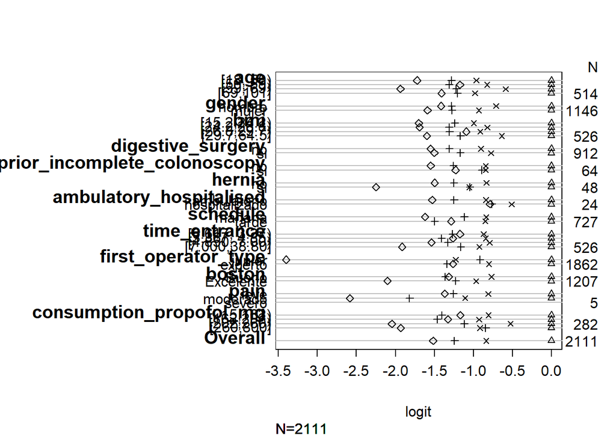

```r
plot(supuestos_model2, which=1:5,pch=1:5,xlab='logit', main=' ', xlim=range(supuestos_model2[,3:6], finite=T))
```

Modelo (3) sin las variables VEDA/vcc conjunta, preparation, cirugia digestiva

```r
model3 <- clmm(score~age+gender+bmi+prior_incomplete_colonoscopy+schedule+first_operator_type+boston+pain+hernia+time_entrance+ambulatory_hospitalised+consumption_propofol_mg+(1|institution),data=db_imp)

summary(model3)
```

```
## Cumulative Link Mixed Model fitted with the Laplace approximation
##
## formula:
## score ~ age + gender + bmi + prior_incomplete_colonoscopy + schedule +
##     first_operator_type + boston + pain + hernia + time_entrance +
##     ambulatory_hospitalised + consumption_propofol_mg + (1 |      institution)
## data:    db_imp
##
##  link  threshold nobs logLik   AIC     niter      max.grad cond.H
##  logit flexible  2111 -2633.16 5302.32 2158(6486) 1.62e-02 2.9e+06
##
## Random effects:
##  Groups      Name        Variance Std.Dev.
##  institution (Intercept) 0.8073   0.8985
## Number of groups:  institution 15
##
## Coefficients:
##                                       Estimate Std. Error z value Pr(>|z|)
## age                                   0.011334   0.003238   3.501 0.000464 ***
## gendermujer                           0.596254   0.085718   6.956 3.50e-12 ***
## bmi                                  -0.017995   0.008665  -2.077 0.037829 *
## prior_incomplete_colonoscopysi        0.530696   0.242714   2.187 0.028779 *
## scheduletarde                         0.324207   0.097489   3.326 0.000882 ***
## first_operator_typeexperto           -0.657845   0.146766  -4.482 7.38e-06 ***
## bostonExcelente                      -0.382784   0.097677  -3.919 8.90e-05 ***
## painmoderado                          0.683620   0.145965   4.683 2.82e-06 ***
## painsevero                            0.304987   0.700005   0.436 0.663060
## herniasi                              0.546835   0.270722   2.020 0.043392 *
## time_entrance                         0.047036   0.012119   3.881 0.000104 ***
## ambulatory_hospitalisedhospitalizado -0.146329   0.436350  -0.335 0.737364
## consumption_propofol_mg               0.002852   0.000614   4.644 3.41e-06 ***
## ---
## Signif. codes:  0 '***' 0.001 '**' 0.01 '*' 0.05 '.' 0.1 ' ' 1
##
## Threshold coefficients:
##     Estimate Std. Error z value
## 1|2   0.3445     0.4389   0.785
## 2|3   1.9760     0.4410   4.481
## 3|4   2.9994     0.4436   6.761
## 4|5   4.6708     0.4548  10.269
```

```r
exp(coef(model3))
```

```
##                                  1|2                                  2|3
##                            1.4113303                            7.2137073
##                                  3|4                                  4|5
##                           20.0729810                          106.7848106
##                                  age                          gendermujer
##                            1.0113989                            1.8153066
##                                  bmi       prior_incomplete_colonoscopysi
##                            0.9821659                            1.7001151
##                        scheduletarde           first_operator_typeexperto
##                            1.3829336                            0.5179664
##                      bostonExcelente                         painmoderado
##                            0.6819603                            1.9810364
##                           painsevero                             herniasi
##                            1.3566071                            1.7277765
##                        time_entrance ambulatory_hospitalisedhospitalizado
##                            1.0481600                            0.8638739
##              consumption_propofol_mg
##                            1.0028558
```

```r
exp(confint(model3))
```

```
##                                           2.5 %      97.5 %
## 1|2                                   0.5970799   3.3359913
## 2|3                                   3.0392452  17.1218737
## 3|4                                   8.4137474  47.8888358
## 4|5                                  43.7865601 260.4222791
## age                                   1.0050009   1.0178376
## gendermujer                           1.5345698   2.1474019
## bmi                                   0.9656262   0.9989889
## prior_incomplete_colonoscopysi        1.0565247   2.7357538
## scheduletarde                         1.1424005   1.6741111
## first_operator_typeexperto            0.3884852   0.6906034
## bostonExcelente                       0.5631402   0.8258510
## painmoderado                          1.4881507   2.6371694
## painsevero                            0.3440400   5.3493279
## herniasi                              1.0163625   2.9371525
## time_entrance                         1.0235561   1.0733553
## ambulatory_hospitalisedhospitalizado  0.3673062   2.0317604
## consumption_propofol_mg               1.0016496   1.0040633
```

```r
sf3 <- function(y){
c('y>=1' = qlogis(mean(y >= 1)),
'y>=2' = qlogis(mean(y >= 2)),
'y>=3' = qlogis(mean(y >= 3)),
'y>=4' = qlogis(mean(y >= 4)),
'y>=5' = qlogis(mean(y >= 5)))
}

supuestos_model3 <- with(db_imp,summary(as.numeric(score) ~ age+gender+bmi+prior_incomplete_colonoscopy+ambulatory_hospitalised+schedule+first_operator_type+boston+pain+hernia+time_entrance+consumption_propofol_mg, fun=sf3))

supuestos_model3
```

```
## as.numeric(score)      N= 2111
##
## +----------------------------+-------------+----+----+-----------+----------+----------+---------+
## |                            |             |   N|y>=1|       y>=2|      y>=3|      y>=4|     y>=5|
## +----------------------------+-------------+----+----+-----------+----------+----------+---------+
## |                         age|     [18, 50)| 532| Inf| 0.35713146|-0.9255195|-1.8870696|-3.610918|
## |                            |     [50, 59)| 538| Inf| 0.40701430|-0.9046099|-1.7302342|-2.902206|
## |                            |     [59, 69)| 527| Inf| 0.27883246|-0.9403239|-1.5274429|-3.463781|
## |                            |     [69,101]| 514| Inf| 0.77603484|-0.4265869|-1.4083271|-2.816853|
## +----------------------------+-------------+----+----+-----------+----------+----------+---------+
## |                      gender|       hombre| 965| Inf| 0.09333194|-1.1847629|-1.8959288|-3.309899|
## |                            |        mujer|1146| Inf| 0.76872986|-0.5061745|-1.4372467|-3.026390|
## +----------------------------+-------------+----+----+-----------+----------+----------+---------+
## |                         bmi|  [15.2,24.2)| 543| Inf| 0.76870759|-0.4688067|-1.4640721|-3.164708|
## |                            |  [24.2,26.8)| 515| Inf| 0.31719613|-0.9951152|-1.8169037|-3.506558|
## |                            |  [26.8,29.7)| 527| Inf| 0.30985593|-0.9974163|-1.9095425|-2.999724|
## |                            |  [29.7,64.5]| 526| Inf| 0.40071451|-0.7653286|-1.4006144|-2.997730|
## +----------------------------+-------------+----+----+-----------+----------+----------+---------+
## |prior_incomplete_colonoscopy|           no|2047| Inf| 0.43158904|-0.8266786|-1.6674165|-3.215325|
## |                            |           si|  64| Inf| 1.01693426| 0.1251631|-0.7166777|-1.945910|
## +----------------------------+-------------+----+----+-----------+----------+----------+---------+
## |     ambulatory_hospitalised|  ambulatorio|2087| Inf| 0.45725272|-0.7911071|-1.6296991|-3.159251|
## |                            |hospitalizado|  24| Inf|-0.33647224|-1.0986123|-1.6094379|-2.397895|
## +----------------------------+-------------+----+----+-----------+----------+----------+---------+
## |                    schedule|       mañana|1384| Inf| 0.44658336|-0.6715481|-1.5071713|-3.129479|
## |                            |        tarde| 727| Inf| 0.45037766|-1.0461115|-1.8950125|-3.180923|
## +----------------------------+-------------+----+----+-----------+----------+----------+---------+
## |         first_operator_type|       junior| 249| Inf| 1.43210390| 0.5172565|-0.7112746|-4.114964|
## |                            |      experto|1862| Inf| 0.33831386|-0.9993689|-1.8005590|-3.064966|
## +----------------------------+-------------+----+----+-----------+----------+----------+---------+
## |                      boston|        Bueno| 904| Inf| 0.95612419|-0.4082314|-1.1768477|-2.493325|
## |                            |    Excelente|1207| Inf| 0.10448601|-1.1241834|-2.0887961|-4.190496|
## +----------------------------+-------------+----+----+-----------+----------+----------+---------+
## |                        pain|         leve|1896| Inf| 0.31264870|-0.9441477|-1.7529196|-3.122365|
## |                            |     moderado| 210| Inf| 2.14539951| 0.3266842|-0.7801586|-3.367296|
## |                            |       severo|   5| Inf|        Inf| 1.3862944|      -Inf|     -Inf|
## +----------------------------+-------------+----+----+-----------+----------+----------+---------+
## |                      hernia|           no|2063| Inf| 0.43219817|-0.8195215|-1.6513196|-3.147190|
## |                            |           si|  48| Inf| 1.21302264| 0.1670541|-0.8873032|-3.135494|
## +----------------------------+-------------+----+----+-----------+----------+----------+---------+
## |               time_entrance|[0.617, 3.37)| 561| Inf|-0.04635411|-1.3121864|-2.1795250|-3.350827|
## |                            |[3.367, 4.85)| 495| Inf| 0.34687094|-1.0638959|-1.9072250|-3.167583|
## |                            |[4.850, 7.00)| 529| Inf| 0.61198377|-0.7130625|-1.5063895|-3.046505|
## |                            |[7.000,38.80]| 526| Inf| 0.96606563|-0.1983665|-1.1241239|-3.040546|
## +----------------------------+-------------+----+----+-----------+----------+----------+---------+
## |     consumption_propofol_mg|    [ 15,162)| 540| Inf| 0.54654371|-0.8561318|-1.6637499|-2.833213|
## |                            |    [162,202)| 773| Inf| 0.54338825|-0.9217305|-1.8503278|-3.175362|
## |                            |    [202,260)| 282| Inf| 0.15634607|-0.9614112|-1.4868356|-3.533687|
## |                            |    [260,800]| 516| Inf| 0.36845364|-0.4737844|-1.3887186|-3.320228|
## +----------------------------+-------------+----+----+-----------+----------+----------+---------+
## |                     Overall|             |2111| Inf| 0.44788971|-0.7943896|-1.6294672|-3.146923|
## +----------------------------+-------------+----+----+-----------+----------+----------+---------+
```

```r
supuestos_model3[, 6] <- supuestos_model3[, 6] - supuestos_model3[, 5]
supuestos_model3[, 5] <- supuestos_model3[, 5] - supuestos_model3[, 4]
supuestos_model3[, 4] <- supuestos_model3[, 4] - supuestos_model3[, 3]
supuestos_model3[, 3] <- supuestos_model3[, 3] - supuestos_model3[, 3]
supuestos_model3
```

```
## as.numeric(score)      N= 2111
##
## +----------------------------+-------------+----+----+----+----------+----------+----------+
## |                            |             |   N|y>=1|y>=2|      y>=3|      y>=4|      y>=5|
## +----------------------------+-------------+----+----+----+----------+----------+----------+
## |                         age|     [18, 50)| 532| Inf|   0|-1.2826510|-0.9615501|-1.7238483|
## |                            |     [50, 59)| 538| Inf|   0|-1.3116242|-0.8256244|-1.1719720|
## |                            |     [59, 69)| 527| Inf|   0|-1.2191564|-0.5871190|-1.9363379|
## |                            |     [69,101]| 514| Inf|   0|-1.2026218|-0.9817401|-1.4085260|
## +----------------------------+-------------+----+----+----+----------+----------+----------+
## |                      gender|       hombre| 965| Inf|   0|-1.2780949|-0.7111659|-1.4139700|
## |                            |        mujer|1146| Inf|   0|-1.2749043|-0.9310722|-1.5891429|
## +----------------------------+-------------+----+----+----+----------+----------+----------+
## |                         bmi|  [15.2,24.2)| 543| Inf|   0|-1.2375143|-0.9952653|-1.7006355|
## |                            |  [24.2,26.8)| 515| Inf|   0|-1.3123113|-0.8217884|-1.6896542|
## |                            |  [26.8,29.7)| 527| Inf|   0|-1.3072722|-0.9121262|-1.0901818|
## |                            |  [29.7,64.5]| 526| Inf|   0|-1.1660431|-0.6352858|-1.5971159|
## +----------------------------+-------------+----+----+----+----------+----------+----------+
## |prior_incomplete_colonoscopy|           no|2047| Inf|   0|-1.2582676|-0.8407379|-1.5479087|
## |                            |           si|  64| Inf|   0|-0.8917711|-0.8418408|-1.2292325|
## +----------------------------+-------------+----+----+----+----------+----------+----------+
## |     ambulatory_hospitalised|  ambulatorio|2087| Inf|   0|-1.2483598|-0.8385920|-1.5295516|
## |                            |hospitalizado|  24| Inf|   0|-0.7621401|-0.5108256|-0.7884574|
## +----------------------------+-------------+----+----+----+----------+----------+----------+
## |                    schedule|       mañana|1384| Inf|   0|-1.1181314|-0.8356233|-1.6223078|
## |                            |        tarde| 727| Inf|   0|-1.4964892|-0.8489010|-1.2859108|
## +----------------------------+-------------+----+----+----+----------+----------+----------+
## |         first_operator_type|       junior| 249| Inf|   0|-0.9148474|-1.2285311|-3.4036893|
## |                            |      experto|1862| Inf|   0|-1.3376828|-0.8011901|-1.2644071|
## +----------------------------+-------------+----+----+----+----------+----------+----------+
## |                      boston|        Bueno| 904| Inf|   0|-1.3643556|-0.7686163|-1.3164776|
## |                            |    Excelente|1207| Inf|   0|-1.2286695|-0.9646127|-2.1017000|
## +----------------------------+-------------+----+----+----+----------+----------+----------+
## |                        pain|         leve|1896| Inf|   0|-1.2567964|-0.8087719|-1.3694453|
## |                            |     moderado| 210| Inf|   0|-1.8187153|-1.1068428|-2.5871373|
## |                            |       severo|   5| Inf|    |      -Inf|      -Inf|          |
## +----------------------------+-------------+----+----+----+----------+----------+----------+
## |                      hernia|           no|2063| Inf|   0|-1.2517197|-0.8317981|-1.4958707|
## |                            |           si|  48| Inf|   0|-1.0459686|-1.0543573|-2.2481910|
## +----------------------------+-------------+----+----+----+----------+----------+----------+
## |               time_entrance|[0.617, 3.37)| 561| Inf|   0|-1.2658323|-0.8673386|-1.1713020|
## |                            |[3.367, 4.85)| 495| Inf|   0|-1.4107668|-0.8433292|-1.2603575|
## |                            |[4.850, 7.00)| 529| Inf|   0|-1.3250463|-0.7933270|-1.5401151|
## |                            |[7.000,38.80]| 526| Inf|   0|-1.1644322|-0.9257573|-1.9164224|
## +----------------------------+-------------+----+----+----+----------+----------+----------+
## |     consumption_propofol_mg|    [ 15,162)| 540| Inf|   0|-1.4026755|-0.8076181|-1.1694634|
## |                            |    [162,202)| 773| Inf|   0|-1.4651187|-0.9285974|-1.3250342|
## |                            |    [202,260)| 282| Inf|   0|-1.1177572|-0.5254244|-2.0468510|
## |                            |    [260,800]| 516| Inf|   0|-0.8422380|-0.9149343|-1.9315097|
## +----------------------------+-------------+----+----+----+----------+----------+----------+
## |                     Overall|             |2111| Inf|   0|-1.2422793|-0.8350776|-1.5174557|
## +----------------------------+-------------+----+----+----+----------+----------+----------+
```

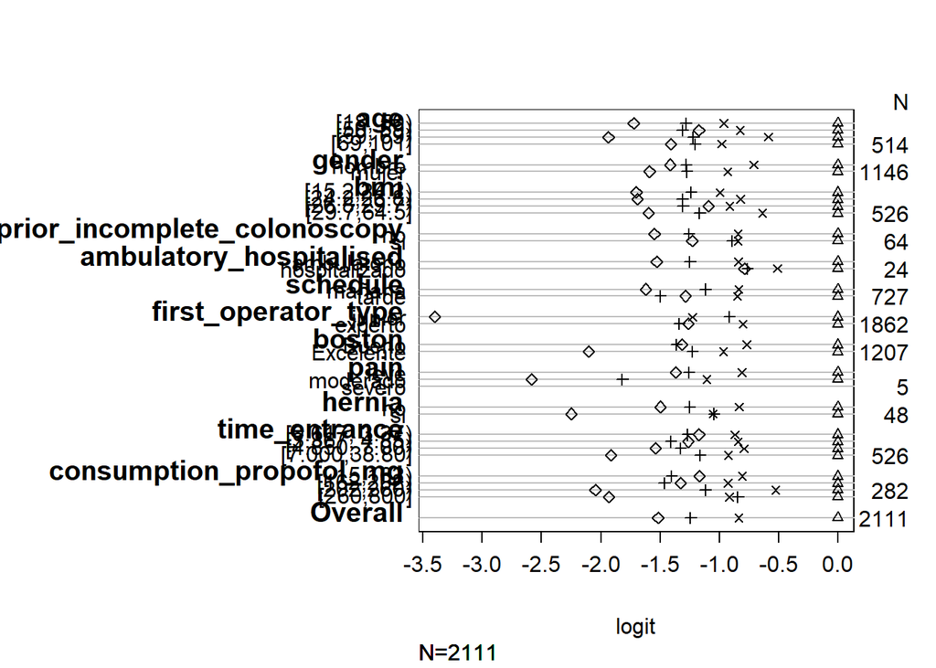

```r
plot(supuestos_model3, which=1:5,pch=1:5,xlab='logit', main=' ', xlim=range(supuestos_model3[,3:6], finite=TRUE))#
```

Modelo 4 sin variables VEDA/vcc conjunta, preparation, cirugia digestiva y hernia

```r
model4 <- clmm(score~age+gender+bmi+prior_incomplete_colonoscopy+schedule+first_operator_type+boston+pain+time_entrance+ambulatory_hospitalised+consumption_propofol_mg+(1|institution),data=db_imp)
```

```r
# model2c <- clmm2(score~age+gender+bmi+digestive_surgery+prior_incomplete_colonoscopy+hernia+ambulatory_hospitalised+ schedule +time_entrance+first_operator_type+boston+pain+consumption_propofol_mg, random = institution, nominal=~age+gender+bmi+digestive_surgery+prior_incomplete_colonoscopy+hernia+ambulatory_hospitalised+ schedule +time_entrance+first_operator_type+boston+pain+consumption_propofol_mg, data=db_imp, Hess=T)
# summary(model2c)

#1 - pchisq(2*(logLik(model2c)-logLik(model2_asess)),df=df.residual(model2_asess)-df.residual(model2c))
#o
#anova(model2_asess,model2c)#no cumple segun LRT
```

```r
compare_performance(model1,model2,model3,model4)#RMSE 2.20 el error es el mismo, AIC no disminuye demasiado con una variable menos (model3), vuelve a aumentar al sacar mas variables en model 4, continuamos con el modelo2 por ahora
```

```
## # Comparison of Model Performance Indices
##
## Name   | Model |  AIC (weights) |  BIC (weights) |  RMSE | Sigma
## ----------------------------------------------------------------
## model1 |  clmm | 5306.4 (0.063) | 5436.5 (<.001) | 2.207 | 1.814
## model2 |  clmm | 5303.4 (0.282) | 5410.8 (0.005) | 2.208 | 1.814
## model3 |  clmm | 5302.3 (0.481) | 5404.1 (0.139) | 2.208 | 1.814
## model4 |  clmm | 5304.3 (0.175) | 5400.5 (0.856) | 2.208 | 1.814
```

```r
# Predict values of the ordinal target variable in the test dataset:
preds <- predict(ordforres, newdata=datatest)

perf<-perff_equal(ytest=datatest$score, ytestpred=as.ordered(preds$ypred))
#estadistico Youden 0.144 en promedio

#matriz de confusion
caret::confusionMatrix(preds$ypred, datatest$score)
```

```
## Confusion Matrix and Statistics
##
##           Reference
## Prediction   1   2   3   4   5
##          1 237 139  50  34  14
##          2  14  31  16  15   2
##          3   7  11  13   5   1
##          4  13  31  26  35   9
##          5   0   0   0   1   0
##
## Overall Statistics
##
##                Accuracy : 0.4489
##                  95% CI : (0.4117, 0.4865)
##     No Information Rate : 0.3849
##     P-Value [Acc > NIR] : 0.0003137
##
##                   Kappa : 0.1881
##
##  Mcnemar's Test P-Value : < 2.2e-16
##
## Statistics by Class:
##
##                      Class: 1 Class: 2 Class: 3 Class: 4 Class: 5
## Sensitivity            0.8745  0.14623  0.12381  0.38889  0.00000
## Specificity            0.4527  0.90447  0.95993  0.87134  0.99853
## Pos Pred Value         0.5000  0.39744  0.35135  0.30702  0.00000
## Neg Pred Value         0.8522  0.71086  0.86207  0.90678  0.96302
## Prevalence             0.3849  0.30114  0.14915  0.12784  0.03693
## Detection Rate         0.3366  0.04403  0.01847  0.04972  0.00000
## Detection Prevalence   0.6733  0.11080  0.05256  0.16193  0.00142
## Balanced Accuracy      0.6636  0.52535  0.54187  0.63011  0.49926
```

```r
#accuracy(precision de la clasif en datos de testeo): 0.44
#AUC del modelo mixto para predecir datos de entrenamiento y armar la curva
model2_asess <- clmm2(score~age+gender+bmi+digestive_surgery+prior_incomplete_colonoscopy+hernia+ambulatory_hospitalised+ schedule +time_entrance+first_operator_type+boston+pain+consumption_propofol_mg, random=institution,data=db_imp, Hess=T )
summary(model2_asess)
```

```
## Cumulative Link Mixed Model fitted with the Laplace approximation
##
## Call:
## clmm2(location = score ~ age + gender + bmi + digestive_surgery +
##     prior_incomplete_colonoscopy + hernia + ambulatory_hospitalised +
##     schedule + time_entrance + first_operator_type + boston +
##     pain + consumption_propofol_mg, random = institution, data = db_imp,
##     Hess = T)
##
## Random effects:
##                   Var   Std.Dev
## institution 0.8078769 0.8988197
##
## Location coefficients:
##                                      Estimate Std. Error z value Pr(>|z|)
## age                                   0.0109   0.0033     3.3467 0.00081767
## gendermujer                           0.5778   0.0878     6.5798 4.7113e-11
## bmi                                  -0.0187   0.0087    -2.1527 0.03134417
## digestive_surgerysi                   0.0858   0.0889     0.9651 0.33451803
## prior_incomplete_colonoscopysi        0.5220   0.2428     2.1503 0.03153205
## herniasi                              0.5344   0.2705     1.9757 0.04819394
## ambulatory_hospitalisedhospitalizado -0.1412   0.4365    -0.3234 0.74639537
## scheduletarde                         0.3325   0.0979     3.3968 0.00068190
## time_entrance                         0.0468   0.0121     3.8642 0.00011143
## first_operator_typeexperto           -0.6498   0.1470    -4.4208 9.8333e-06
## bostonExcelente                      -0.3836   0.0977    -3.9267 8.6114e-05
## painmoderado                          0.6755   0.1462     4.6219 3.8025e-06
## painsevero                            0.3145   0.7012     0.4485 0.65380293
## consumption_propofol_mg               0.0029   0.0006     4.6966 2.6454e-06
##
## No scale coefficients
##
## Threshold coefficients:
##     Estimate Std. Error z value
## 1|2  0.3425   0.4387     0.7807
## 2|3  1.9744   0.4408     4.4790
## 3|4  2.9981   0.4434     6.7611
## 4|5  4.6699   0.4546    10.2719
##
## log-likelihood: -2632.693
## AIC: 5303.386
## Condition number of Hessian: 2910172.59
```

```r
exp(coef(model2_asess))
```

```
##                                  1|2                                  2|3
##                            1.4084776                            7.2022915
##                                  3|4                                  4|5
##                           20.0474074                          106.6918365
##                                  age                          gendermujer
##                            1.0109867                            1.7820583
##                                  bmi                  digestive_surgerysi
##                            0.9814445                            1.0896305
##       prior_incomplete_colonoscopysi                             herniasi
##                            1.6854338                            1.7065078
## ambulatory_hospitalisedhospitalizado                        scheduletarde
##                            0.8683522                            1.3943811
##                        time_entrance           first_operator_typeexperto
##                            1.0479646                            0.5221354
##                      bostonExcelente                         painmoderado
##                            0.6814078                            1.9651111
##                           painsevero              consumption_propofol_mg
##                            1.3695475                            1.0028947
##
##                            2.4567019
```

```r
model_predict2 <- predict(model2_asess, newdata=datatest, type="response")

acu2<-multiclass.roc(datatest$score, model_predict2,direction=">", levels=levels(datatest$score),plot=TRUE, print.thres="best", print.auc=T)
acu2$auc
```

```
## Multi-class area under the curve: 0.9402
```

```r
roc.df2<-data.frame(tpp=acu2$rocs[[10]]$sensitivities*100, ## tpp = true positive percentage
  tnp=acu2$rocs[[10]]$specificities*100, ## fpp = false positive precentage
  thresholds=acu2$rocs[[10]]$thresholds)

roc.df2[roc.df2$tpp > 90 & roc.df2$tpp < 95,]#0.027
```

```
##         tpp      tnp thresholds
## 33 92.30769 33.33333 0.13269926
## 34 92.30769 34.44444 0.13119126
## 35 92.30769 35.55556 0.12934731
## 36 92.30769 36.66667 0.12705219
## 37 92.30769 37.77778 0.12555203
## 38 92.30769 38.88889 0.12521529
## 39 92.30769 40.00000 0.12506555
## 40 92.30769 41.11111 0.12399661
## 41 92.30769 42.22222 0.12264951
## 42 92.30769 43.33333 0.12218725
## 43 92.30769 44.44444 0.12057833
## 44 92.30769 45.55556 0.11840348
## 45 92.30769 46.66667 0.11767414
## 46 92.30769 47.77778 0.11729579
```

[output cut: 44 more lines]

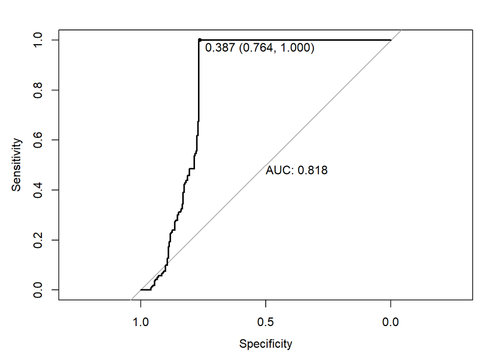

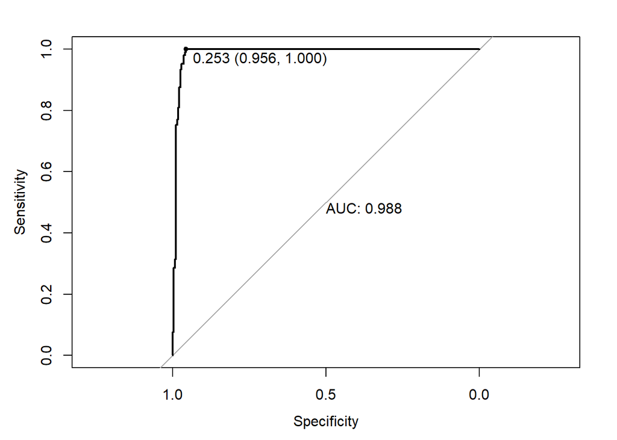

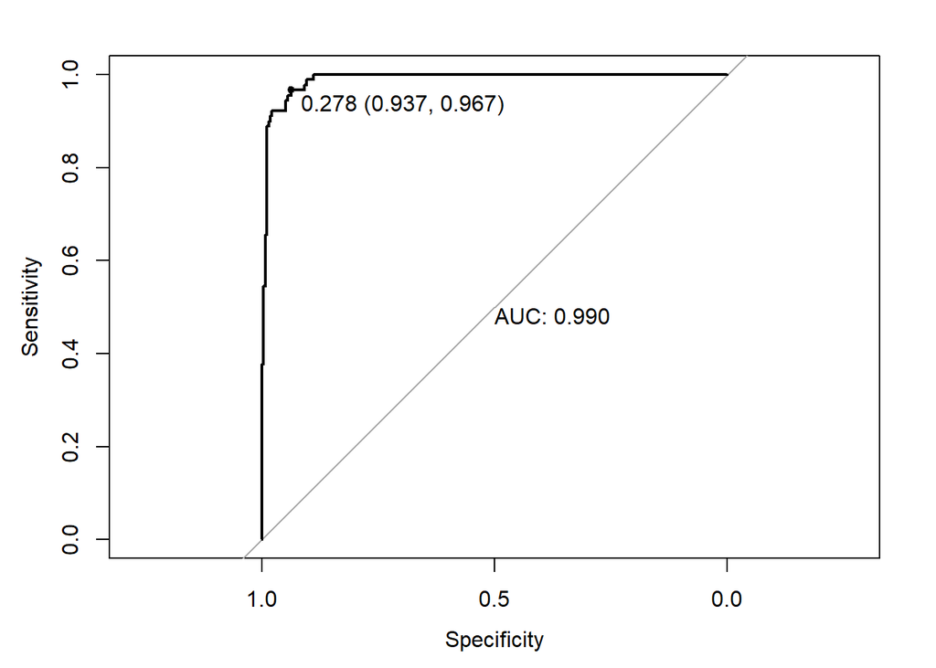

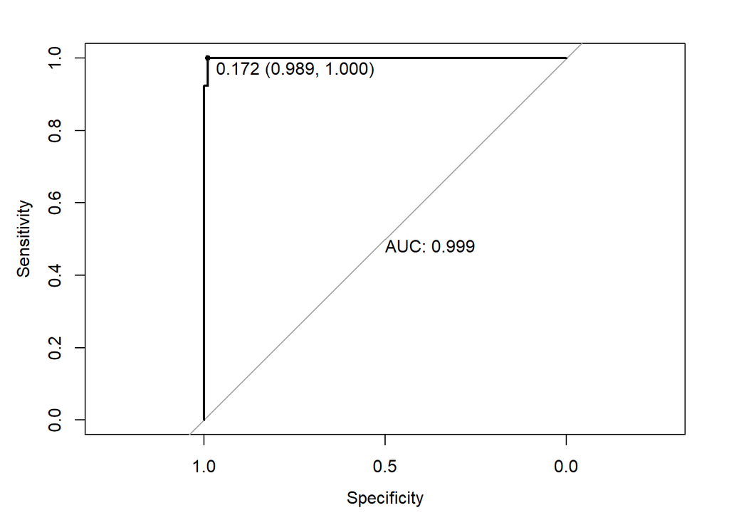

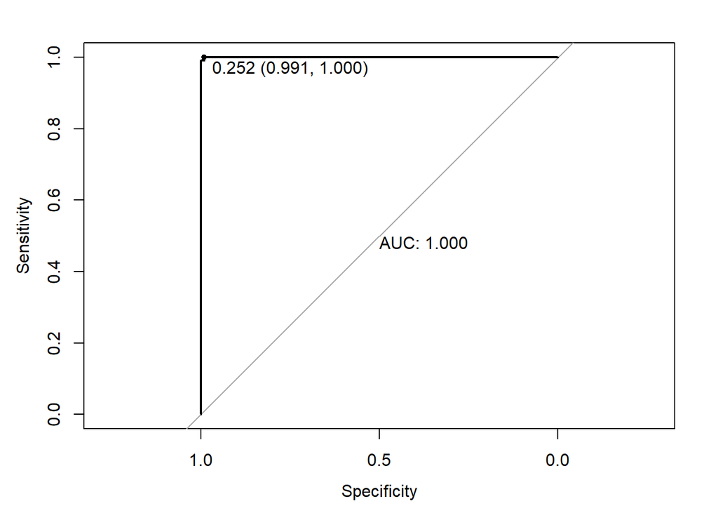

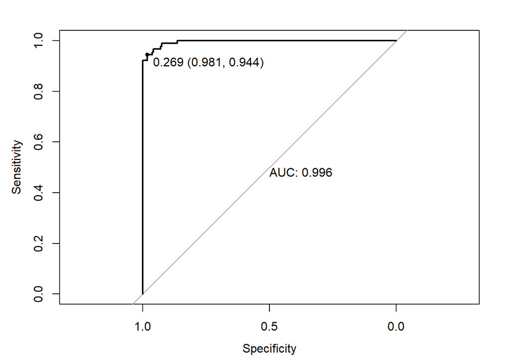

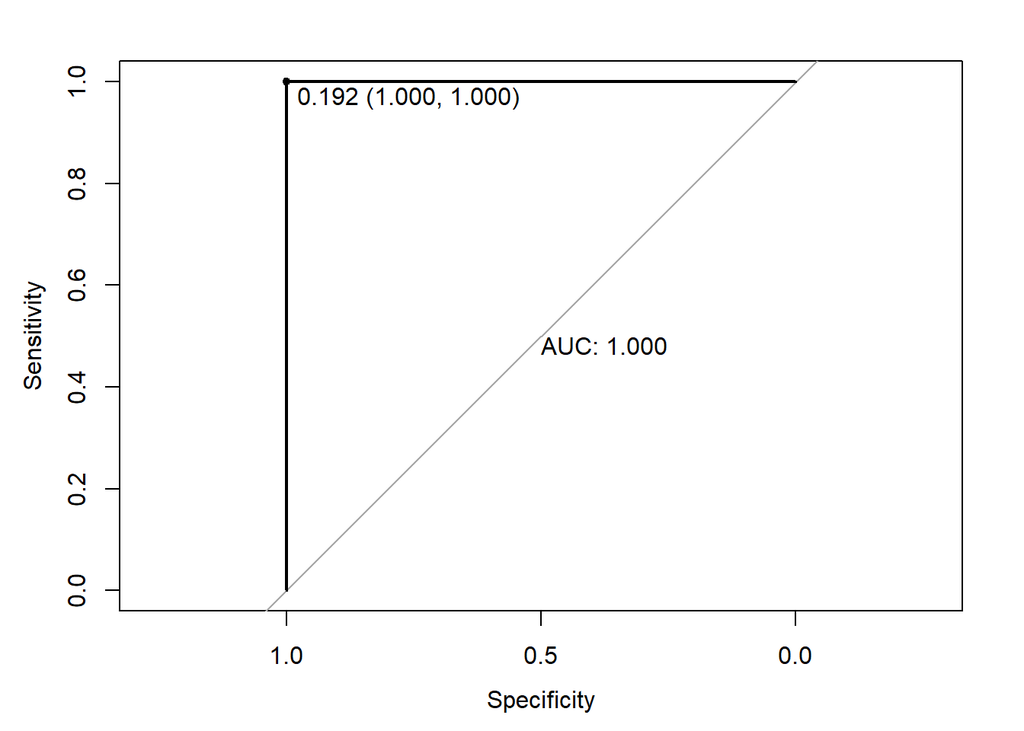

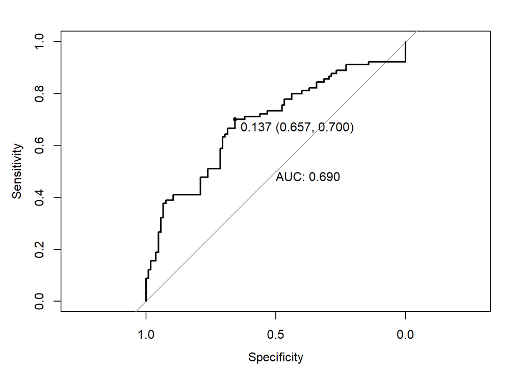

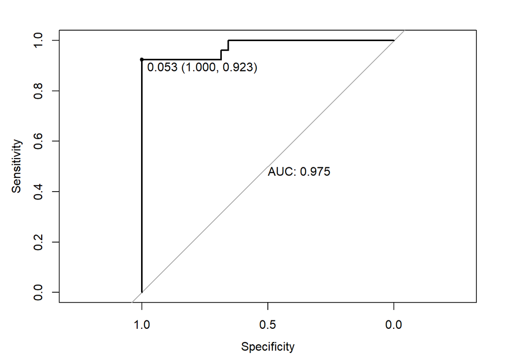

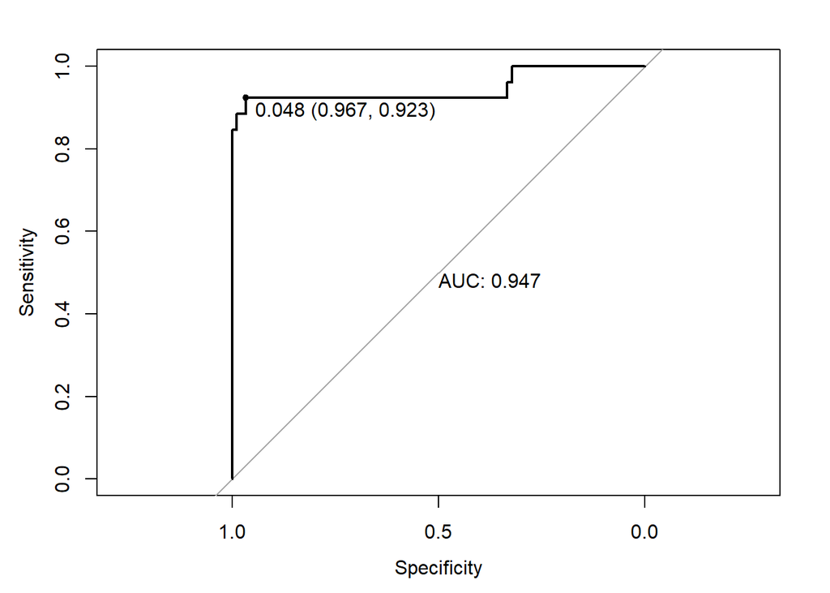

```r
curva_roc<-ggroc(acu2$rocs[[10]],alpha = 1, colour = "red", linetype = 1, size = 1)+ ggtitle("Gráfico 2. Curva ROC") + labs(x="Especificidad", y="Sensibilidad")+annotate("text", x=0.60,y=0.50,label="AUC=0.95",fontface = "bold",size = 4)+
  theme(plot.title = element_text(size = 14, face = "bold"),axis.title = element_text(size=13))+annotate("pointrange",x=0.965,y=0.923,ymin = 0.916,ymax = 0.93,colour="black",size=0.5)+annotate("text",x=0.70,y=0.80, label="S:92.3% E:96.7%", fontface = "bold",size = 5)
```

```r
model3_asess <- clmm2(score~age+gender+bmi+prior_incomplete_colonoscopy+schedule+first_operator_type+boston+pain+hernia+time_entrance+ambulatory_hospitalised+consumption_propofol_mg, random=institution,data=db_imp, Hess=T )
summary(model2_asess)
```

```
## Cumulative Link Mixed Model fitted with the Laplace approximation
##
## Call:
## clmm2(location = score ~ age + gender + bmi + digestive_surgery +
##     prior_incomplete_colonoscopy + hernia + ambulatory_hospitalised +
##     schedule + time_entrance + first_operator_type + boston +
##     pain + consumption_propofol_mg, random = institution, data = db_imp,
##     Hess = T)
##
## Random effects:
##                   Var   Std.Dev
## institution 0.8078769 0.8988197
##
## Location coefficients:
##                                      Estimate Std. Error z value Pr(>|z|)
## age                                   0.0109   0.0033     3.3467 0.00081767
## gendermujer                           0.5778   0.0878     6.5798 4.7113e-11
## bmi                                  -0.0187   0.0087    -2.1527 0.03134417
## digestive_surgerysi                   0.0858   0.0889     0.9651 0.33451803
## prior_incomplete_colonoscopysi        0.5220   0.2428     2.1503 0.03153205
## herniasi                              0.5344   0.2705     1.9757 0.04819394
## ambulatory_hospitalisedhospitalizado -0.1412   0.4365    -0.3234 0.74639537
## scheduletarde                         0.3325   0.0979     3.3968 0.00068190
## time_entrance                         0.0468   0.0121     3.8642 0.00011143
## first_operator_typeexperto           -0.6498   0.1470    -4.4208 9.8333e-06
## bostonExcelente                      -0.3836   0.0977    -3.9267 8.6114e-05
## painmoderado                          0.6755   0.1462     4.6219 3.8025e-06
## painsevero                            0.3145   0.7012     0.4485 0.65380293
## consumption_propofol_mg               0.0029   0.0006     4.6966 2.6454e-06
##
## No scale coefficients
##
## Threshold coefficients:
##     Estimate Std. Error z value
## 1|2  0.3425   0.4387     0.7807
## 2|3  1.9744   0.4408     4.4790
## 3|4  2.9981   0.4434     6.7611
## 4|5  4.6699   0.4546    10.2719
##
## log-likelihood: -2632.693
## AIC: 5303.386
## Condition number of Hessian: 2910172.59
```

```r
exp(coef(model3_asess))
```

[output not shown]

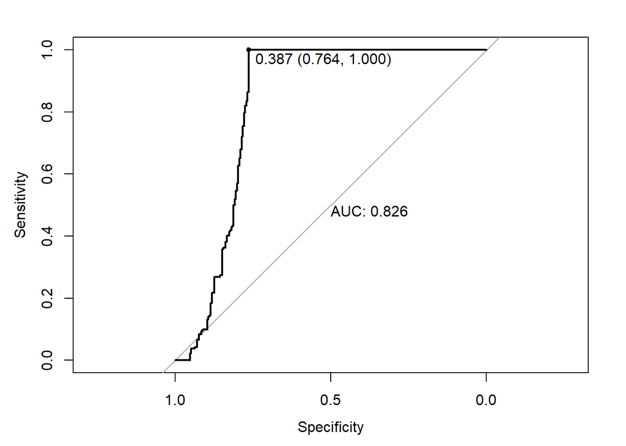

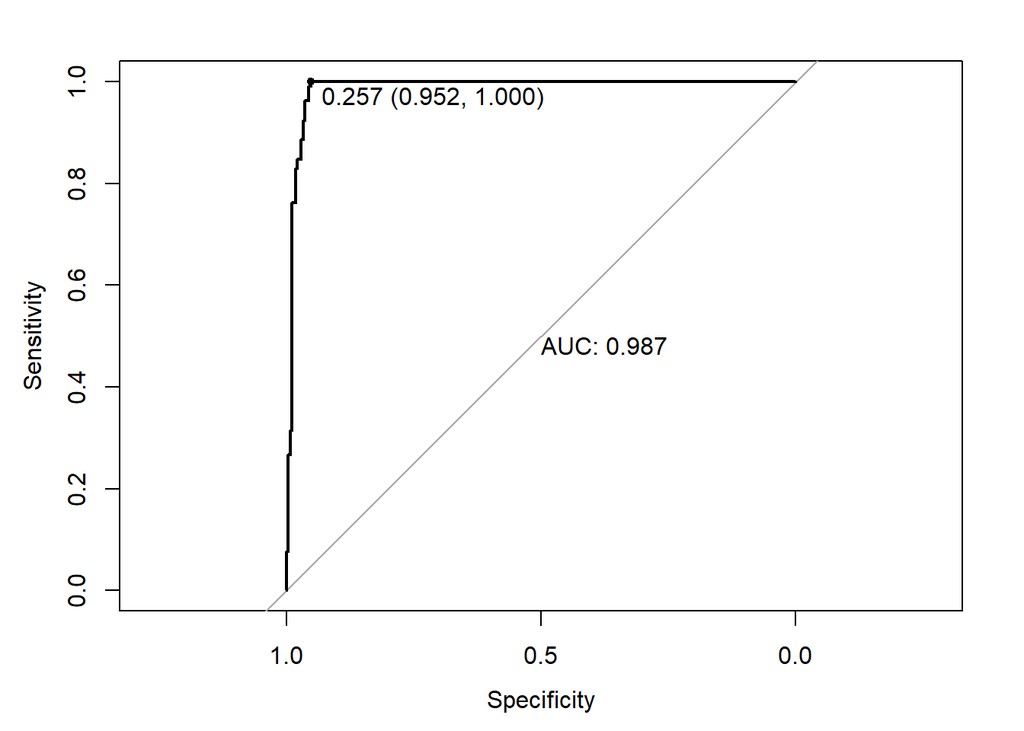

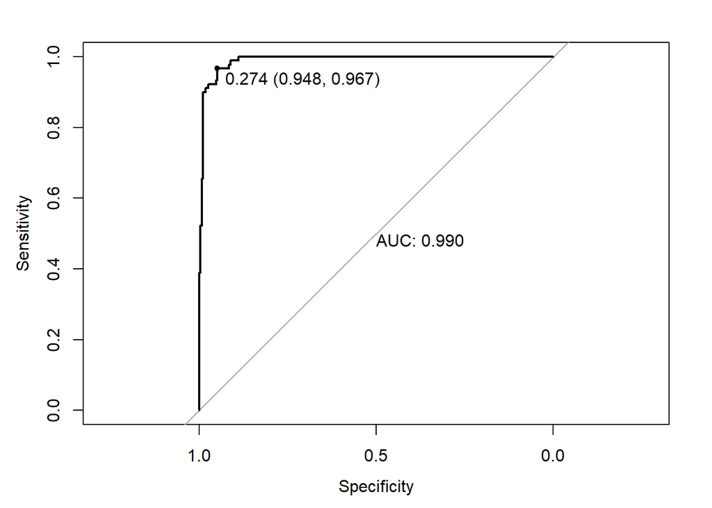

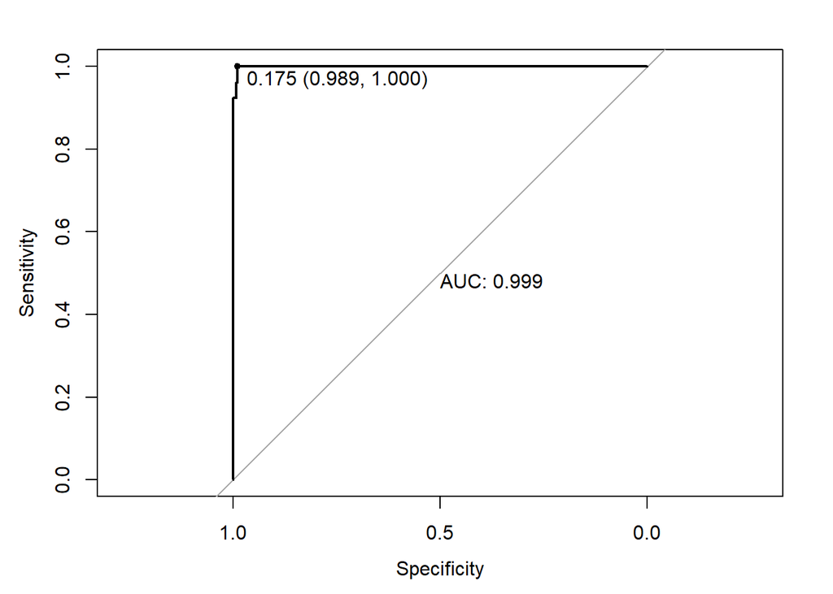

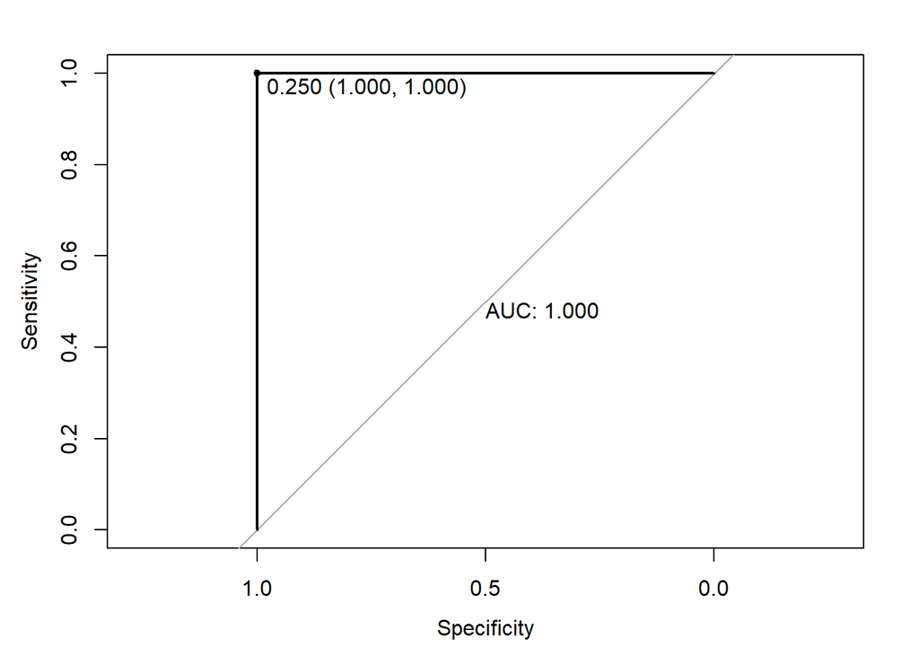

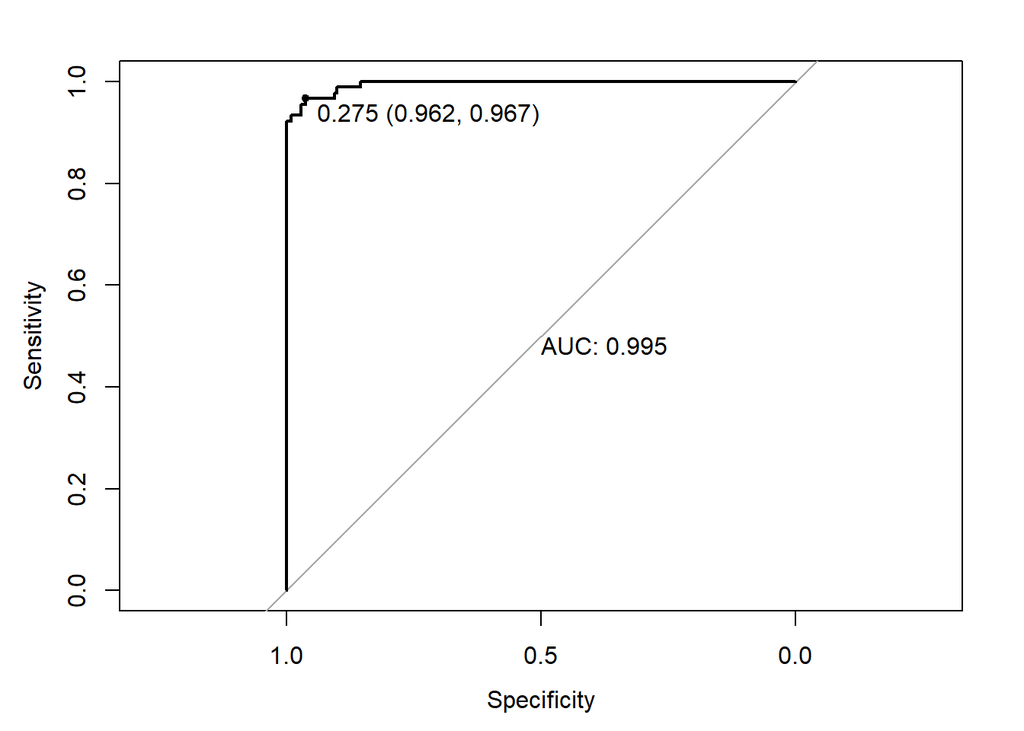

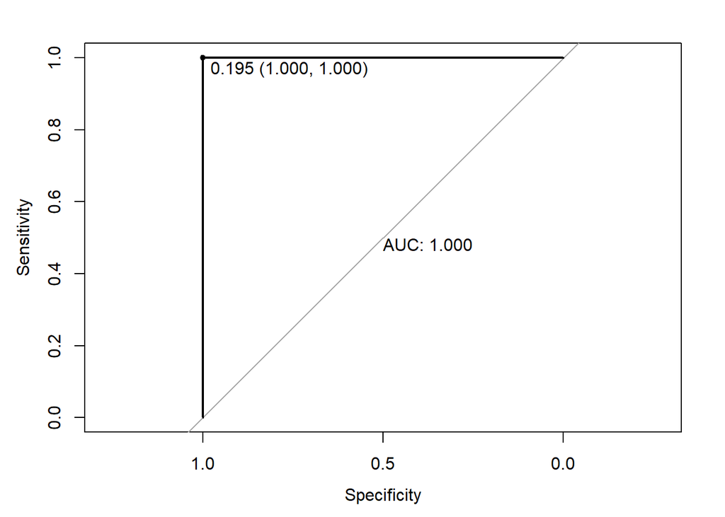

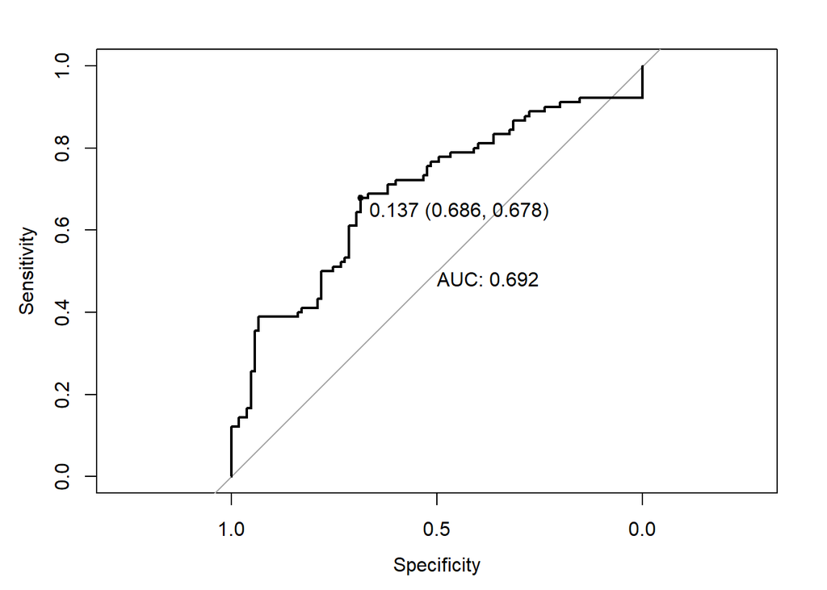

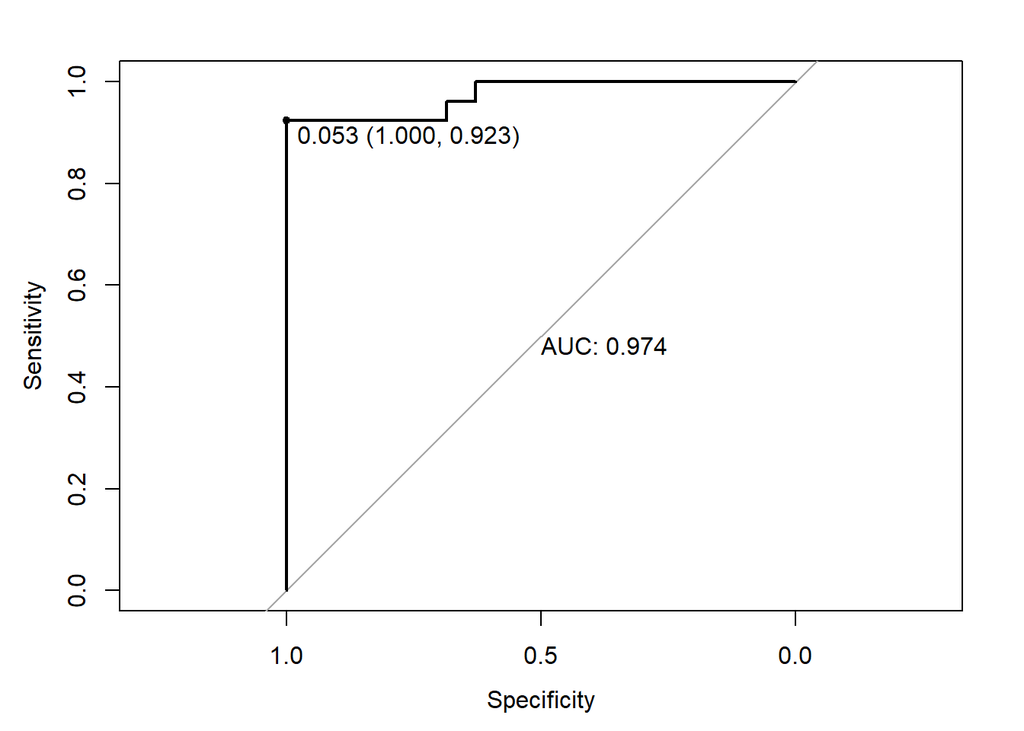

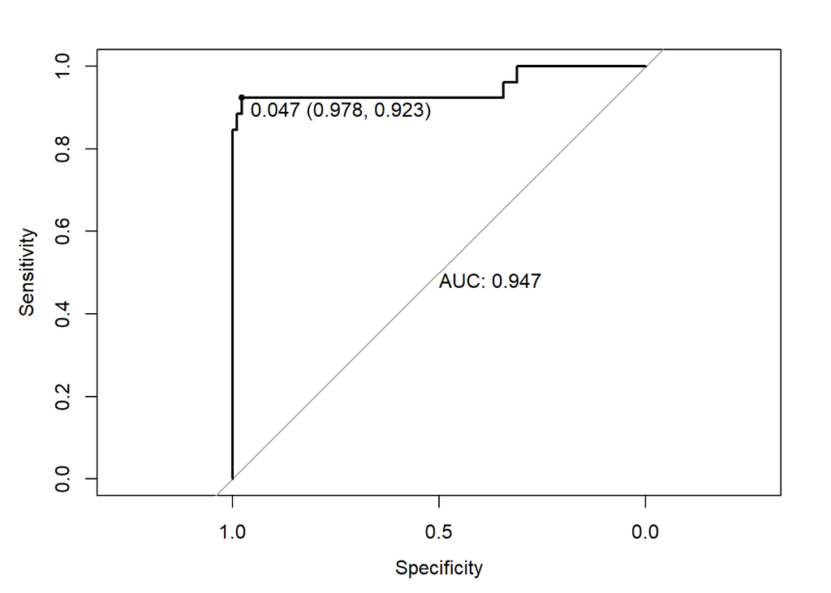

```r
model_predict3 <- predict(model3_asess, newdata=datatest, type="probability")

auc3 <- multiclass.roc(datatest$score, model_predict3,direction=">", levels=levels(datatest$score),plot=TRUE, print.thres="best", print.auc=T)#0.95 averange
```

```r
auc3$auc# no hay mcuha diferencia
```

```
## Multi-class area under the curve: 0.941
```

Continuamos con el modelo 2

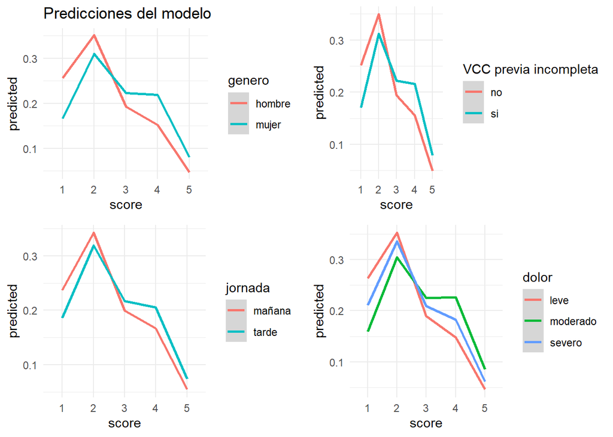

```r
ggpredictions <-data.frame(ggpredict(model2,terms="gender", type="fe"))

ggpredictions$x = factor(ggpredictions$x)
levels(ggpredictions$x) = c("hombre", "mujer")
colnames(ggpredictions)[c(1, 6)] =c("genero", "score")

graf1<-ggplot(ggpredictions, aes(x = score, y = predicted, group=genero)) +
  geom_smooth(aes(colour = genero),span=0.9)+
  theme_minimal()+
  ggtitle("Predicciones del modelo")

predictions2<-data.frame(ggpredict(model2,terms="pain", type="fe"))

predictions2$x = factor(predictions2$x)
levels(predictions2$x) = c("leve", "moderado","severo")
colnames(predictions2)[c(1,6)] =c("dolor", "score")

graf2<-ggplot(predictions2, aes(x = score, y = predicted, group=dolor))+geom_smooth(aes(colour = dolor),span=0.9)+theme_minimal()

predictions3<-data.frame(ggpredict(model2,terms="schedule", type="fe"))

predictions3$x = factor(predictions3$x)
levels(predictions3$x) = c("mañana", "tarde")
colnames(predictions3)[c(1, 6)] =c("jornada", "score")

graf3<-ggplot(predictions3, aes(x = score, y = predicted, group=jornada))+geom_smooth(aes(colour = jornada),span=0.9)+theme_minimal()

predictions4<-data.frame(ggpredict(model2,terms="prior_incomplete_colonoscopy", type="fe"))

predictions4$x = factor(predictions4$x)
levels(predictions4$x) = c("no", "si")
colnames(predictions4)[c(1, 6)] =c("VCCincompleta", "score")


graf4<-ggplot(predictions4, aes(x = score, y = predicted, group=VCCincompleta))+geom_smooth(aes(colour = VCCincompleta),span=0.9)+theme_minimal()+labs(color="VCC previa incompleta")


plot_grid(graf1,graf4,graf3,graf2)
```

# 7 **Resultados**

```r
mylabels2<-list(age="Edad",gendermujer="Genero[mujer]",bmi="IMC",digestive_surgerysi="Cirugia abdominal",herniasi="Antecedentes de hernia",prior_incomplete_colonoscopysi="Colonoscopia previa incompleta",ambulatory_hospitalisedhospitalizado="Hospitalizado",first_operator_typeexperto="1°operador experto", bostonExcelente="Boston[excelente]",scheduletarde="VCC vespertina",time_entrance="Tiempo de entrada(min)",painmoderado="Dolor[moderado]",painsevero="Dolor[severo]",consumption_propofol_mg="Consumo de propofol(mg)")


?tab_model
tabla_modelo<-tab_model(model2,rm.terms=c("1|2","2|3","3|4","4|5"),title = "Tabla 4. Resultados", auto.label = T,string.pred = "Predictores", string.ci = "IC 95%",dv.labels = "Score ABCD",pred.labels =mylabels2)
tabla_modelo
```

Tabla 4. Resultados

|  | Score ABCD |  |  |
| --- | --- | --- | --- |
| Predictores | Odds Ratios | IC 95% | p |
| Edad | 1.01 | 1.00 – 1.02 | **0.001** |
| Genero[mujer] | 1.78 | 1.50 – 2.12 | **<0.001** |
| IMC | 0.98 | 0.96 – 1.00 | **0.031** |
| Cirugia abdominal | 1.09 | 0.92 – 1.30 | 0.335 |
| Colonoscopia previa incompleta | 1.69 | 1.05 – 2.71 | **0.032** |
| Antecedentes de hernia | 1.71 | 1.00 – 2.90 | **0.048** |
| Hospitalizado | 0.87 | 0.37 – 2.04 | 0.746 |
| VCC vespertina | 1.39 | 1.15 – 1.69 | **0.001** |
| Tiempo de entrada(min) | 1.05 | 1.02 – 1.07 | **<0.001** |
| 1°operador experto | 0.52 | 0.39 – 0.70 | **<0.001** |
| Boston[excelente] | 0.68 | 0.56 – 0.83 | **<0.001** |
| Dolor[moderado] | 1.97 | 1.48 – 2.62 | **<0.001** |
| Dolor[severo] | 1.37 | 0.35 – 5.41 | 0.654 |
| Consumo de propofol(mg) | 1.00 | 1.00 – 1.00 | **<0.001** |
| Random Effects |  |  |  |
| σ<sup>2</sup> | 3.29 |  |  |
| τ<sub>00</sub> <sub>institution</sub> | 0.81 |  |  |
| ICC | 0.20 |  |  |
| N <sub>institution</sub> | 15 |  |  |
| Observations | 2111 |  |  |
| Marginal R<sup>2</sup> / Conditional R<sup>2</sup> | 0.095 / 0.273 |  |  |

```r
tbl_regression(model2, exponentiate=T)
```

| **Characteristic** | **OR**<sup>1</sup> | **95% CI**<sup>1</sup> | **p-value** |
| --- | --- | --- | --- |
| age | 1.01 | 1.00, 1.02 | <0.001 |
| gender |  |  |  |
| hombre | — | — |  |
| mujer | 1.78 | 1.50, 2.12 | <0.001 |
| bmi | 0.98 | 0.96, 1.00 | 0.031 |
| digestive_surgery |  |  |  |
| no | — | — |  |
| si | 1.09 | 0.92, 1.30 | 0.3 |
| prior_incomplete_colonoscopy |  |  |  |
| no | — | — |  |
| si | 1.69 | 1.05, 2.71 | 0.032 |
| hernia |  |  |  |
| no | — | — |  |
| si | 1.71 | 1.00, 2.90 | 0.048 |
| ambulatory_hospitalised |  |  |  |
| ambulatorio | — | — |  |
| hospitalizado | 0.87 | 0.37, 2.04 | 0.7 |
| schedule |  |  |  |
| mañana | — | — |  |
| tarde | 1.39 | 1.15, 1.69 | <0.001 |
| time_entrance | 1.05 | 1.02, 1.07 | <0.001 |
| first_operator_type |  |  |  |
| junior | — | — |  |
| experto | 0.52 | 0.39, 0.70 | <0.001 |
| boston |  |  |  |
| Bueno | — | — |  |
| Excelente | 0.68 | 0.56, 0.83 | <0.001 |
| pain |  |  |  |
| leve | — | — |  |
| moderado | 1.97 | 1.48, 2.62 | <0.001 |
| severo | 1.37 | 0.35, 5.41 | 0.7 |
| consumption_propofol_mg | 1.00 | 1.00, 1.00 | <0.001 |

<sup>1</sup> OR = Odds Ratio, CI = Confidence Interval

```r
summary(model2)
```

Cumulative Link Mixed Model fitted with the Laplace approximation

formula: score ~ age + gender + bmi + digestive_surgery + prior_incomplete_colonoscopy +  
hernia + ambulatory_hospitalised + schedule + time_entrance +  
first_operator_type + boston + pain + consumption_propofol_mg +  
(1 | institution) data: db_imp

link threshold nobs logLik AIC niter max.grad cond.H logit flexible 2111 -2632.69 5303.39 2293(6891) 1.31e-01 2.9e+06

Random effects: Groups Name Variance Std.Dev. institution (Intercept) 0.8078 0.8988  
Number of groups: institution 15

Threshold coefficients: Estimate Std. Error z value 1|2 0.3425 0.4390 0.780 2|3 1.9744 0.4411 4.476 3|4 2.9981 0.4437 6.757 4|5 4.6699 0.4549 10.266

```r
exp(coef(model2))
```

```
                             1|2                                  2|3
                       1.4084536                            7.2021820
                             3|4                                  4|5
                      20.0470553                          106.6898705
                             age                          gendermujer
                       1.0109865                            1.7820606
                             bmi                  digestive_surgerysi
                       0.9814444                            1.0896225
  prior_incomplete_colonoscopysi                             herniasi
                       1.6854441                            1.7065466
```

ambulatory_hospitalisedhospitalizado scheduletarde 0.8683706 1.3943762 time_entrance first_operator_typeexperto 1.0479640 0.5221339 bostonExcelente painmoderado 0.6814069 1.9651138 painsevero consumption_propofol_mg 1.3693621 1.0028947

```r
or<-odds_plot(model2,title = "Gráfico 1. Estimadores modelo de regresion ordinal",
              subtitle = "Factores asociados a VCC dificultosa",
              error_bar_width = 1,
              point_size = 2,
              point_col = "red",
              error_bar_colour = "blue", x_label = "",h_line_color = "black")
?odds_plot
or$odds_data<-or$odds_data[-c(1,2,3),]
or$odds_plot$data<-or$odds_plot$data[-c(1,2,3),]

or_plot<-or$odds_plot+
  scale_x_discrete(expand=c(0.15,0.15),labels=c("prior_incomplete_colonoscopysi"="Colonoscopia previa incompleta",
"painmoderado" = "Dolor moderado","painsevero"="Dolor severo",
"gendermujer"="Mujer",
"herniasi"="Hernia","scheduletarde"="VCC vespertina","digestive_surgerysi"="Cirugia digestiva","time_entrance"="Tiempo de entrada","age"="Edad","consumption_propofol_mg"="Consumo de propofol(mg)","bmi"="IMC","ambulatory_hospitalisedhospitalizado"="Hospitalizado","bostonExcelente"="Boston Excelente","first_operator_typeexperto"="1°operador experto"))+theme(axis.text = element_text(size=14,face="bold", colour="black"),plot.title = element_text(size = 14, face = "bold"), plot.subtitle =element_text(size = 14), axis.title =element_text(size=12))
```